# FS / GRF / DINA on the ACTG175 binary (OR) harm DGM — MR (field) template, batchable

Binary twin of the continuous/MD field template: the field block, the complement field (field-s) and the joint pair on the odds-ratio scale

Author

Larry F. León

Published

September 19, 2026

> **Template (`TASK_actg175_binary_campaign_2026-09-17` §1.3).** One committed file runs every cell of the ACTG175 binary/OR design: each knob reads an `FS_OR_*` environment variable first and falls back to the in-file default, so an unattended driver renders `FS_OR_TARGET=1.5 FS_OR_N=2000 FS_OR_CAMPAIGN=orfs quarto render <this file> --output …` without editing the template. Every resolved value is echoed below and lands in the bundle’s `meta`. The committed study (`maxeffCons_mr_coverage_sweep_or075.qmd` and its `mr_sweep/` payloads) is not touched: this document writes under its own stem token (`mr_field`), its own results root (`mr_or_harm/`) and a mandatory campaign tag, and refuses to overwrite any git-tracked bundle.

# 1 What this evaluates

Per replicate, identify $\hat H$ on the ACTG175-anchored binary/OR super-population with one of three identifiers (`FS_OR_METHOD` = `consistency` | `grf` | `dina`) under `sg_focus = "effMaxSG"` and the band rule, then compute — on the same data and the same selected subgroup — the within-subgroup odds ratio and its intervals:

- **oracle** $\hat\theta(Q)$ — logistic refit on the true region, with its Wald interval;
- **naive** $\hat\theta(\hat H)$ — the plug-in on the selected region with its Wald interval;
- **MR (IJ)** $\tilde\theta(\hat H)$ — the two-term de-biased multiplier-resampling estimate with its infinitesimal-jackknife interval (the construction the committed study ran, there as its only one);
- **MR (field)** — `ci_method = "field"`: the shrunk-field estimator `est2` and the Λ*-quantile intervals; its **one-sided lower bound** (harm claim) is the directional product on $\hat H$;
- **complement field** (`field_complement = TRUE`) and its **field-s** companion (`field_scale_complement = "selected"`) — Λ*ᶜ from the same multipliers and winners; the **one-sided upper bound** on $\hat H^{c}$ is the directional product there;
- **joint pair** — simultaneous ($\hat H$ lower, $\hat H^{c}$ upper) from the aligned draws: separate / Bonferroni / calibrated, with `joint_s` mirroring the field-s pair;
- **FB** — never run and never joined on this path (there is no committed FB bundle for the binary design): the `fb_*` recorder columns are kept for schema parity with the MD template and stay all-NA.

Scoring uses the exact conditional estimand $\beta(\hat H)$ on the DGM super-population (`fs_attach_betaHhat()` on the full evaluation frame), the per-replicate oracle, and the study’s two population references — $\theta^{\dagger}$ (the marginal OR in the block) and $\theta^{\ddagger}$ (the controlled direct effect) — recorded per replicate as `C_dagger_*` / `C_ddagger_*`.

**Scale and orientation.** `adverse_outcome = TRUE`: the analysis runs directly on the adverse outcome `y_neg` (“no CD4 improvement at week 20”), so **OR > 1 is harm** and no orientation flip is applied anywhere — `.orient` is the identity. Every estimate and every bound in this document is an **odds ratio** (positive); biases are reported both as OR differences and, in SD units, on the **log-OR** scale. Bounds are read by **location against clinically meaningful OR thresholds** (the ladder τ = 0.7, 0.8, 0.9, 1.0, 1.25, 1.5, 2.0), never as significance at OR = 1: on $\hat H$ a lower bound ≥ τ reads “harm of at least τ”; on $\hat H^{c}$ an upper bound ≤ τ reads “harm of at most τ”.

**Conditional-family reading (governing constraint).** GRF’s and DINA’s candidate families are generated from fitted surfaces, so the fixed-family condition does not hold for them: **every coverage figure on those two paths is coverage of the estimand conditional on the proposed family.** FS’s family is the prespecified cut grid. Comparisons across the three identifiers are descriptive.

## 1.1 Swap ledger — every deviation from the two sources, named

Sources, quoted throughout: **[MD]** = `../continuous/sim_fs_maxeffCons_mr_field_md_template.qmd` (the structure being copied); **[S]** = `maxeffCons_mr_coverage_sweep_or075.qmd` (the committed study driver, this task’s source for the data recipe, seeds, truths and detector settings); **[S10]**/**[S15]** = `../binary/mr_coverage_sweep_or10.qmd` / `mr_coverage_sweep_or15.qmd` (consulted for `target_or_h` and calibration settings only).

| block | taken from | change |
| --- | --- | --- |
| YAML, prose, chunk order, summary layer | [MD] :1–15, :30–89, :1235–2019 | retitled; the scale is the OR (see below) |
| knobs | [MD] :93–374 | renamed `FS_OR_*`; `FS_OR_TARGET` and `FS_OR_N` replace `FS_MD_MD`/`FS_MD_N`; `FS_MD_KNOISE`, `FS_MD_BUILD`, `FS_MD_QUICKRUN`, `FS_MD_FB*`, `FS_MD_UNIFORM`, `FS_MD_DMIN_GRF` and `FS_MD_JOIN_SKIP` drop… |
| the band-width guard | [MD] :156–164 | a NOTE replaces the hard error: [MD]’s default eps was the package’s own (0.10), so unset reproduced its committed renders; here the default is the campaign’s 0.20, and §1.5(a) must render the STUDY’s… |
| data preparation, DGM build, truth, evaluation frame | [S] :233–341 verbatim | `target_effect = FS_OR_TARGET` only ([S] :245 `target_or_h`; reachable range `k_inter_range = c(0.3, 1.5)` is [S] :222, and is [S10] :222 / [S15] :222 unchanged) |
| seed table and per-replicate seeding | [S] :119–133, :447–456 verbatim | none |
| per-replicate data preparation (id, factor→numeric, confounders, noise offset) | [S] :457–484 verbatim | none |
| oracle | [S] :360–380 (`.logit_or_ci`) | recorded under [MD]’s `or_*` names, not [S]’s `ora_*`, so `fs_sim_bias_coverage(target = "oracle")` reads it unrenamed |
| thresholds and search settings | [S] :175–207 | `sg_focus`, `effect_neighborhood`, `selection_rule` from the knobs (the dispositions: `effMaxSG`, 0.20, `neighborhood`) in place of [S]’s `maxeffCons` / 0.10 |
| GRF and DINA arguments | [S] :205–207 verbatim | none (`dmin.grf = 0.0`, frontier/effect/depth 2; DINA `effect`, `dina_args = list()`) |
| MR arguments | [MD] :343–348 | [S]’s `ci_method = "ij"` ([S] :516) replaced by the field list; `consistency_method = "resample"` is [S] :179, which MR requires |
| recorder columns | [MD] :516–636 unchanged in naming | **added**: `seed` ([S] :512, a data-level Gate 2 column) and `C_dagger_H/Hc`, `C_ddagger_H/Hc` ([S]’s truth table, per replicate, beside `betaHhat_*`) |
| `betaHhat` attachment | [S] :703–707 verbatim | none |
| `meta` and poolability keys | [MD] :1135–1175, :1210–1225 | plus `target_or_h`, the five truths, `sg_quantile`, `n_super`, `eval_seed`, `seed_scheme`, `outcome_type`, `effect_measure` and the thresholds ([S] :716–748) |
| stem and results directory | [MD] :190–216 | `mr_or_harm/` root; design token `or075`/`or100`/`or150` and `n` in the stem |
| `fs_dgm_scale()` / the SCALE CHECK | [MD] :442, :1367–1377 | **dropped**: `fs_dgm_scale()` refuses ratio measures (`R/fs_dgm_scale.R:130`). `dgm_scale <- NULL`, so [MD]’s own `is.null()` guards skip the check and the payload’s `scale` element |
| `fs_mr_oc_summary()` | [MD] :1136, :1215 | kept; the truth list carries `effect_Q`/`effect_Qc`/`prevalence_Q`/`beta_inter` aliases (`R/fs_mr_oc_summary.R:131–190` reads those names) beside the study’s own |
| reference-target slots | [MD] :1331–1339 | `struct`/`marg` renamed `dagger`/`ddagger` = θ† / θ‡, the study’s two population references |
| working vs effect scale | `R/fs_mr_inference.R:480–488` | recorded as a fact, not a change: `lambda_mean`, `lambda_sd`/`se_field` and the seven Λ* quantiles are on the **working** (log-OR) scale, while `est2` and every bound are on the **effect** (OR) scale.… |
| bound-location ladder | [MD] :1557–1593 | the dispositions’ OR ladder on **both** blocks |
| `fs_sim_bias_coverage()` scale | [MD] :1719, :1857 (`"identity"`) | `"log"` (the OR is a ratio measure) |
| `fs_identification_summary()` triple | [MD] :1904–1938 | **dropped**: `anchor`/`partner`/`proxy` is the MD design’s age / preanti / str2; the binary true region {wtkg > q70} ∩ {cd40 > q70} has no binary proxy and `proxy` has no default (`R/fs_identification… |
| FB join | [MD] :1052–1080 | **dropped** (no committed binary FB bundle); `fb_mode` pinned `"none"`, `fb_*` columns kept all-NA |

# 2 Setup — all knobs

```r
.t0_doc <- Sys.time()   # start of document wall-clock (total reported at the end)
# forestsearch must be INSTALLED (devtools::install()), not load_all(): the
# doFuture workers spawn separate R processes that only see the installed
# package.  ([MD] :96-98)
library(forestsearch)
suppressPackageStartupMessages({
  library(speff2trial); library(doFuture); library(foreach); library(data.table)
})

# ── Environment overrides (FS_OR_*) ─────────────────────────────────────────
# [MD] :104-107, renamed.
.env_chr <- function(k, d) { v <- Sys.getenv(k, unset = NA); if (is.na(v) || !nzchar(v)) d else v }
.env_int <- function(k, d) as.integer(.env_chr(k, d))
.env_num <- function(k, d) as.numeric(.env_chr(k, d))

# ── Parallelization topology ────────────────────────────────────────────────
# "sims": replicates fan out across workers; the search and the MR gate run
# sequentially within each replicate.  [MD] :109-116; [S] :108-117 makes the
# same choice for the same reason (no inner bootstrap).
parallel_mode <- "sims"
.phys_minus1 <- max(1L, parallel::detectCores(logical = FALSE) - 1L)
n_workers    <- min(.env_int("FS_OR_WORKERS", .phys_minus1), .phys_minus1)

# ── Counts ──────────────────────────────────────────────────────────────────
n_sims       <- .env_int("FS_OR_NSIMS", 1000L)   # replicates in THIS batch
diag_mode    <- FALSE   # TRUE caps to 5 reps and relays worker errors verbatim
nb_boots     <- NULL    # FB is NEVER run in this document; see fb_mode
mr_draws     <- 5000L   # MR multiplier draws ([S] :86, the committed value)
k_random_noise <- 0L    # [S] :129, pinned: no noise confounders on this design

# ── Batching across renders (seed-disjoint pieces; pool via combine) ────────
# Seeds come from the pre-generated table indexed by GLOBAL sim_id ([S]
# :119-133), so disjoint sim_id ranges across renders pool to exactly one big
# run and results are invariant to worker count and batch position.
run_mode     <- .env_chr("FS_OR_MODE", "batch")   # "batch" (run + save one piece) | "combine" (merge + report)
stopifnot(run_mode %in% c("batch", "combine"))
sim_id_start <- .env_int("FS_OR_START", 1L)

# ── Seeds: PRE-GENERATED, indexed by GLOBAL replicate id ([S] :119-133) ─────
# VERBATIM from the study driver, including MAX_SIMS = 5000 and the generator
# state at the point of the draw (R's default kind; the per-replicate switch to
# L'Ecuyer-CMRG happens inside record_replicate(), after this table is built).
seed_base  <- 8316951L
MAX_SIMS   <- 5000L
set.seed(seed_base)
SEED_TABLE <- sample.int(.Machine$integer.max - 1L, MAX_SIMS)
seed_for <- function(sim_id) {
  if (sim_id < 1L || sim_id > MAX_SIMS)
    stop("sim_id ", sim_id, " outside the pre-generated seed table.")
  SEED_TABLE[sim_id]
}
seed_scheme <- "pre-generated table indexed by global sim_id"

# ── The identifier: engine + focus (these ARE the estimator; they feed the stem)
# [MD] :133-148, renamed.  Default-inert: unset resolves to "consistency".
subgroup_method <- .env_chr("FS_OR_METHOD", "consistency")  # "consistency" | "dina" | "grf"
stopifnot(subgroup_method %in% c("consistency", "dina", "grf"))
sg_focus        <- .env_chr("FS_OR_FOCUS", "effMaxSG")      # the dispositions' rule
stopifnot(sg_focus %in% c("effMaxSG", "maxeffCons", "effMinSG", "maxSG", "minSG", "maxeff"))
.band_foci <- c("effMaxSG", "effMinSG")
# Band half-width ([MD] :149-164): effect >= (1 - eps) * max effect among the
# qualifying candidates, on the harm-oriented scale; forwarded to the gate
# unchanged by forestsearch() as `nbhd`.  Read HERE, before the stem, because a
# non-default value tags the stem below.
effect_neighborhood <- .env_num("FS_OR_NBHD", 0.20)         # the dispositions' eps
stopifnot(is.finite(effect_neighborhood), effect_neighborhood >= 0, effect_neighborhood < 1)
# DEVIATION from [MD] :156-164, named: [MD] makes a non-band focus with FS_MD_NBHD set a hard
# error, because there its default (0.10) was already forestsearch()'s own, so leaving it unset
# reproduced every committed non-band render exactly.  Here the default is the campaign's 0.20,
# so the same rule would make the STUDY's rule (maxeffCons at eps 0.10) unreachable -- and §1.5(a)
# must render exactly that.  The study driver itself sets effect_neighborhood = 0.10 alongside
# sg_focus = "maxeffCons" ([S] :151-154), so this is the study's own practice.  A NOTE replaces
# the stop, and eps is still recorded in meta and still tags the stem.
if (!sg_focus %in% .band_foci)
  cat(sprintf("NOTE: sg_focus '%s' is not a band focus, so effect_neighborhood = %.2f is forwarded but INERT (the identifier does not consult it); it is still recorded in meta and tags the stem.\n",
              sg_focus, effect_neighborhood))

# ── Cell: design point and sample size ──────────────────────────────────────
# FS_OR_TARGET = the planted marginal OR in the harm subgroup H, the ONLY thing
# that changes between the three design points (the dispositions):
#   0.75 -> the supplement's protective design ([S] :125);
#   1.5  -> harm ([S15] :125);
#   1.0  -> borderline null: the planted region AT the null against a protective
#           complement, as [S10] :125 has it.  [S]'s homogeneous
#           dgm_model = "null" branch ([S] :275-294) is NOT used here.
target_or_h <- .env_num("FS_OR_TARGET", 0.75)
stopifnot(is.finite(target_or_h), target_or_h > 0)
dgm_model   <- "alt"    # pinned: the calibrated planted-region branch ([S] :123)
n_sample    <- .env_int("FS_OR_N", 500L)

method_tag <- if (identical(subgroup_method, "consistency")) "fs" else subgroup_method
# One source of truth: fs_focus_tag() holds the (subgroup_method, sg_focus)
# -> stem tag map for every driver ([MD] :183-188).
focus_tag <- forestsearch::fs_focus_tag(subgroup_method, sg_focus)
if (!identical(focus_tag, sg_focus))
  cat(sprintf("NOTE: sg_focus '%s' is an alias on the %s path; output stem uses focus tag '%s'.\n",
              sg_focus, subgroup_method, focus_tag))

# TEMPLATE STEM (collision guards, [MD] :190-216):
#   1. the token is "mr_field" and the results root is "mr_or_harm", so no
#      output of this document can glob-match the committed study's
#      "mr_sweep/<run_tag>/<method>_mr_n<n>_res.rds" payloads;
#   2. a mandatory campaign_tag suffix namespaces every campaign (smoke vs
#      calibration vs production), so combine_glob can never pool across them.
campaign_tag <- .env_chr("FS_OR_CAMPAIGN", "c1")
stopifnot(grepl("^[A-Za-z0-9]+$", campaign_tag))
# Design token: or075 / or100 / or150 -- the `design` column of the Stage 3
# extract uses the same three strings.
design_tag <- sprintf("or%03d", as.integer(round(100 * target_or_h)))
# Band tag only when non-default ([MD] :197-200), so the 0.10 default would
# leave a stem untagged; this campaign runs 0.20, hence "_nb20".
nbhd_tag <- if (abs(effect_neighborhood - 0.10) < 1e-12) "" else
              sprintf("_nb%02d", round(100 * effect_neighborhood))
rds_stem <- sprintf("%s_%s_mr_field_%s_n%d%s_%s",
                    method_tag, focus_tag, design_tag, n_sample, nbhd_tag, campaign_tag)
# Results directory: [MD] :209-216's layout (no "_s<n_sims>" piece, so
# seed-disjoint batches of different sizes land in one directory and pool),
# under this design's own root.
results_dir <- file.path("mr_or_harm", sprintf("%s_d%d", rds_stem, mr_draws))
if (identical(run_mode, "batch"))
  dir.create(results_dir, recursive = TRUE, showWarnings = FALSE)
sim_id_end    <- sim_id_start + n_sims - 1L
rds_path      <- file.path(results_dir, sprintf("%s_res_%d_%d.rds", rds_stem, sim_id_start, sim_id_end))
combine_glob  <- file.path(results_dir, sprintf("%s_res_*.rds", rds_stem))
combine_files <- NULL    # optional explicit character vector; NULL -> the glob
save_combined <- !identical(.env_chr("FS_OR_SAVE_COMBINED", "TRUE"), "FALSE")
combined_path <- NULL    # NULL -> "<results_dir>/<stem>_combined_<min>_<max>.rds",
                         # deliberately OUTSIDE combine_glob so a re-combine
                         # never re-ingests its own pooled output.
```

```r
# Refuse to overwrite a git-tracked bundle ([MD] :225-239, verbatim): committed
# bundles are read-only, so no committed study path can be written from here.
.refuse_if_tracked <- function(path) {
  tracked <- tryCatch(
    system2("git", c("ls-files", "--error-unmatch", shQuote(path)),
            stdout = FALSE, stderr = FALSE) == 0L,
    error = function(e) FALSE)
  if (isTRUE(tracked))
    stop("refusing to overwrite the git-tracked bundle '", path,
         "': committed bundles are read-only -- use a new campaign_tag.",
         call. = FALSE)
  invisible(path)
}

# ── Search configuration ([S] :178-207; resample identification) ────────────
consistency_method <- "resample"   # [S] :179; MR requires it on the GLM path
selection_rule      <- .env_chr("FS_OR_RULE", "neighborhood")   # the dispositions'
# What the package already requires (.validate_selection_rule(),
# R/subgroup_consistency_helpers.R:743), checked here so it fails before any
# replicate runs rather than inside every one ([MD] :246-252).
if (!identical(selection_rule, "neighborhood") && !sg_focus %in% .band_foci)
  stop(sprintf("selection_rule = '%s' is accepted only for %s; sg_focus = '%s'.",
               selection_rule, paste(.band_foci, collapse = " / "), sg_focus),
       call. = FALSE)
stop_threshold <- NULL   # [S] :182-191: pinned NULL = scan the full family
or_threshold   <- 0.90   # effect.threshold      ([S] :192; OR scale, > 1 = harm)
or_consistency <- 0.80   # consistency.threshold ([S] :193)
pconsistency   <- 0.90   # ([S] :194)
fs_splits <- 500L; maxk <- 2L; n_min <- 60L; d0_min <- 10L; d1_min <- 10L   # [S] :195
use_lasso <- FALSE; use_dina <- FALSE; use_grf <- FALSE; use_twostage <- TRUE # [S] :196
fs_conf.cont_jcuts <- list(cd40 = 10, wtkg = 10)   # [S] :197, J-quantile grids on the two cut vars
fs_max_subgroups_search <- Inf                     # [S] :198
is_rct <- TRUE; vi_grf_min <- -0.2
# ── Per-identifier arguments ([S] :205-207), consumed only under the matching
# subgroup_method (the method_args switch in the call).
grf_selection        <- "frontier"
grf_select_statistic <- "effect"
grf_depth            <- 2L
dmin.grf             <- 0.0       # [S] :206, the study's literal (DR-score harm floor)
dina_args            <- list()    # [S] :207
dina_select_statistic <- "effect" # [S] :207
adverse_outcome <- TRUE   # [S] :176: analyze y_neg directly; OR > 1 = harm

# ── DGM knobs ([S] :122-171, verbatim; do NOT recalibrate) ──────────────────
n_super     <- 100000L    # [S] :124, the study's fixed 100k universe
# sg_quantile: the DESIGN OF RECORD knob.  [S] :126 planted the region at q70
# on both cut variables, prevalence(H) = 9.632%, which fs_dgm_feasibility()
# shows is undeclarable (|Q| <= n.min = 60) in 96% of replicates at n = 500.
# TASK_binary_study_redesign_2026-09-18 Step 1 raised the planted prevalence
# into Larry's 12-15% range, chosen mechanically from the feasibility table
# (feasibility_binary_redesign_2026-09-18.csv): 12.4% is NOT feasible at
# every n at tolerance 0.05, so the rule falls to the smallest feasible
# prevalence in the range, the 15% design point.  q is the MIDPOINT of the
# prevalence plateau (the cuts are taken on the 1083-row ACTG175 analysis
# sample, which carries ties), so the value is robust to rounding.
sg_quantile <- 0.62850    # prevalence(H) = 14.917% (was [S] :126's 0.70 = 9.632%)
cont_vars <- c("age", "preanti", "wtkg", "karnof", "cd40", "cd80")   # [S] :158
bin_vars  <- c("hemo", "homo", "drugs", "race", "gender", "symptom") # [S] :159
subgroup_vars <- c("wtkg", "cd40")                                   # [S] :164
subgroup_cuts <- list(                                               # [S] :165-168
  wtkg = list(type = "greater", quantile = sg_quantile),
  cd40 = list(type = "greater", quantile = sg_quantile))
cal_k_inter_range <- c(0.3, 1.5); cal_grid_step <- 0.025             # [S] :222-223
eval_seed <- 20260628L                                               # [S] :341
outcome_type   <- "binary"    # [S] :174
effect_measure <- "OR"        # [S] :175
# Columns emitted by simulate_from_glm_dgm() ([S] :209-213): the outcome IS the
# event on the binary path, so event.name points at the same y_sim.
outcome_name <- "y_sim"; event_name <- "y_sim"; treat_name <- "treat_sim"
id_name <- "id"; harm_col <- "flag_harm"
confounders_base <- c(cont_vars, bin_vars)
`%||%` <- function(a, b) if (is.null(a) || length(a) == 0 || all(is.na(a))) b else a

# ── MR inference controls (mr_inference_args) ───────────────────────────────
# [MD] :309-348: ci_method "field" computes everything the "ij" path computes --
# the debiased element keeps the IJ interval, so the mr_* (IJ) recorder columns
# are what an "ij" run produces -- and additionally returns the field block
# (fit$mr_inference$field), recorded below as fld_H_*.  field_R_out/field_R_in
# are not forwarded by forestsearch(): the package defaults 1000/500 apply.
mr_ci_method    <- .env_chr("FS_OR_CI", "field")
stopifnot(mr_ci_method %in% c("ij", "field"))
mr_t_confirm    <- NULL       # NULL -> the package's near-null default for this measure (OR 1)
mr_confirm_rule <- "point"
mr_field_uniform <- FALSE     # kappa (uniform) calibration: a closed line, off on this design
mr_field_complement <- identical(.env_chr("FS_OR_FIELD_COMPLEMENT", "TRUE"), "TRUE")
# Complement-scale knob (field-s).  DEFAULT "selected": field-s is the
# recommended complement construction, so unset = recommended.
mr_field_scalec <- .env_chr("FS_OR_FIELD_SCALEC", "selected")
stopifnot(mr_field_scalec %in% c("none", "selected"))
mr_ij_residual <- .env_chr("FS_OR_IJ_RESIDUAL", "two_term")
stopifnot(mr_ij_residual %in% c("two_term", "winner", "winner_floor"))
mr_return_reselection <- identical(.env_chr("FS_OR_RESELECTION", "TRUE"), "TRUE")
show_winner_rows <- identical(.env_chr("FS_OR_WINNER_ROWS", "FALSE"), "TRUE")
mr_inference_args <- c(
  list(ci_method = mr_ci_method, draws = mr_draws, include_complement = TRUE,
       confirm_rule = mr_confirm_rule, field_uniform = mr_field_uniform,
       field_complement = mr_field_complement, ij_residual = mr_ij_residual,
       field_scale_complement = mr_field_scalec,
       return_reselection = mr_return_reselection),
  if (!is.null(mr_t_confirm)) list(t_confirm = mr_t_confirm))
```

```r
# ── FB comparator: never run, never joined on this path ─────────────────────
fb_mode <- "none"   # pinned; there is no committed binary FB bundle to join
run_fb  <- FALSE

cat(sprintf("Batch %d..%d | cell target_or_h=%s n=%d | ci_method=%s complement_field=%s ij_residual=%s reselection=%s scalec=%s | method=%s focus=%s nbhd=%.2f rule=%s | draws=%d | %s x %d workers | campaign=%s\n",
            sim_id_start, sim_id_end, format(target_or_h), n_sample,
            mr_ci_method, mr_field_complement, mr_ij_residual,
            mr_return_reselection, mr_field_scalec, subgroup_method, sg_focus,
            effect_neighborhood, selection_rule, mr_draws, parallel_mode,
            n_workers, campaign_tag))
```

```
Batch 1..1000 | cell target_or_h=0.75 n=500 | ci_method=field complement_field=TRUE ij_residual=two_term reselection=TRUE scalec=selected | method=dina focus=effMaxSG nbhd=0.20 rule=neighborhood | draws=5000 | sims x 13 workers | campaign=ordina
```

```r
cat(sprintf("Output stem: %s\nResults dir: %s\n", rds_stem, results_dir))
```

```
Output stem: dina_effMaxSG_mr_field_or075_n500_nb20_ordina
Results dir: mr_or_harm/dina_effMaxSG_mr_field_or075_n500_nb20_ordina_d5000
```

```r
cat(sprintf("Thresholds (OR scale, > 1 = harm): effect %.2f | consistency %.2f | pconsistency %.2f | n.min %d | d0/d1 %d/%d | maxk %d | splits %d\n",
            or_threshold, or_consistency, pconsistency, n_min, d0_min, d1_min, maxk, fs_splits))
```

```
Thresholds (OR scale, > 1 = harm): effect 0.90 | consistency 0.80 | pconsistency 0.90 | n.min 60 | d0/d1 10/10 | maxk 2 | splits 500
```

# 3 Build the DGM once (n-invariant truth)

The data preparation and the calibration are `[S]` :233–341 verbatim; the only change is `target_effect = target_or_h` from the knob.

```r
# ACTG175, prepped exactly as the Section 6.2 application ([S] :233-240): arm 1
# (ZDV+ddI, experimental) vs arm 3 (ddI, control); week-20 "no CD4 improvement".
actg_df <- subset(speff2trial::ACTG175, arms %in% c(1L, 3L))
actg_df$id    <- seq_len(nrow(actg_df))
actg_df$treat <- ifelse(actg_df$arms == 1L, 1L, 0L)            # ZDV+ddI = 1, ddI = 0
actg_df <- actg_df[!is.na(actg_df$cd420), ]                    # drop missing week-20 CD4
actg_df$y_neg <- 1L - as.integer(actg_df$cd420 > actg_df$cd40) # 1 = no improvement (adverse)

# ALT branch ([S] :242-262): build + calibrate to the target harm OR.
# adverse_outcome = FALSE HERE is INTENTIONAL and is the DGM-CONSTRUCTION
# direction, NOT the analysis direction: with the outcome on the adverse y_neg
# scale, a positive interaction shift plants OR(H) > 1 (harm) directly on the
# analysis scale, while the complement inherits the fitted ACTG175 treatment
# effect (~0.66).  The forestsearch() / oracle calls in the recorder run on the
# SAME y_neg scale with adverse_outcome = TRUE (no flip).
dgm <- calibrate_glm_interaction(
  data            = actg_df,
  factor_vars     = bin_vars,
  continuous_vars = cont_vars,
  outcome_var     = "y_neg",
  treatment_var   = "treat",
  target_effect   = target_or_h,          # <- the ONLY knob-driven change
  outcome_type    = "binary",
  effect_measure  = "OR",
  subgroup_vars   = subgroup_vars,
  subgroup_cuts   = subgroup_cuts,
  k_treat         = 1,
  adverse_outcome = FALSE,
  k_inter_range   = cal_k_inter_range,
  grid_step       = cal_grid_step,
  n_super         = n_super,
  seed            = seed_base)

# truth is ASSEMBLED from the DGM object ([S] :263-270), plus the aliases
# fs_mr_oc_summary() reads (R/fs_mr_oc_summary.R:131-190) and the prevalence.
hr <- dgm$hazard_ratios
truth <- list(
  or_causal = hr$AHR         %||% NA_real_,   # overall marginal OR
  marg_H    = hr$AHR_harm    %||% NA_real_,   # theta-dagger  (H)
  marg_Hc   = hr$AHR_no_harm %||% NA_real_,   # theta-dagger  (Hc)
  cde_H     = hr$CDE_harm    %||% NA_real_,   # theta-ddagger (H)
  cde_Hc    = hr$CDE_no_harm %||% NA_real_)   # theta-ddagger (Hc)
truth$effect_Q     <- truth$marg_H            # alias: fs_mr_oc_summary()'s "struct"
truth$effect_Qc    <- truth$marg_Hc
truth$effect_ITT   <- truth$or_causal
truth$prevalence_Q <- dgm$subgroup_info$proportion %||% NA_real_
truth$beta_inter   <- dgm$model_params$beta_inter  %||% NA_real_
truth$target_or_h  <- target_or_h

# fs_dgm_scale() refuses ratio measures (R/fs_dgm_scale.R:130), so there is no
# sampling-scale object on this design; [MD]'s own is.null() guards then skip
# the SCALE CHECK and leave `scale` out of the payload.
dgm_scale <- NULL

cat(sprintf("DGM truth targets [model = %s, target_or_h = %s] (population, shared by every cell):\n",
            dgm_model, format(target_or_h)))
```

```
DGM truth targets [model = alt, target_or_h = 0.75] (population, shared by every cell):
```

```r
cat(sprintf("  prevalence(H)        : %.2f%%\n", 100 * (truth$prevalence_Q %||% 0)))
```

```
  prevalence(H)        : 14.92%
```

```r
cat(sprintf("  k_inter (beta_inter) : %.7f\n", truth$beta_inter))
```

```
  k_inter (beta_inter) : 0.1513020
```

```r
cat(sprintf("  overall marginal OR  : %.10f\n", truth$or_causal))
```

```
  overall marginal OR  : 0.6722232577
```

```r
cat(sprintf("  theta-dagger  H/Hc   : %.10f / %.10f\n", truth$marg_H, truth$marg_Hc))
```

```
  theta-dagger  H/Hc   : 0.7499999940 / 0.6564077470
```

```r
cat(sprintf("  theta-ddagger H/Hc   : %.10f / %.10f\n", truth$cde_H,  truth$cde_Hc))
```

```
  theta-ddagger H/Hc   : 0.7345268290 / 0.6313905111
```

```r
if (is.finite(truth$marg_H) && abs(truth$marg_H / target_or_h - 1) > 1e-6)
  warning(sprintf("calibration missed the target: marg_H %.6f vs target %.6f (k_inter_range [%s]).",
                  truth$marg_H, target_or_h, paste(cal_k_inter_range, collapse = ", ")),
          call. = FALSE)

# beta(Hhat)-OR evaluation frame ([S] :322-341): the ENTIRE super-population,
# each subject once, under the trials' randomized analysis -- the Theorem-2
# conditional target's evaluation population (one fixed universe).
eval_df <- fs_build_eval_frame(dgm, outcome_type = "binary", eval_seed = eval_seed)
for (v in bin_vars)                 # match the recorder's factor->0/1 coercion
  if (v %in% names(eval_df) && is.factor(eval_df[[v]]))  # so rule evaluation on
    eval_df[[v]] <- as.numeric(as.character(eval_df[[v]]))  # the eval frame == trials
.td_chk <- fs_betaHhat_theta_dagger_check(eval_df, outcome_type = "binary",
                                          harm.name = harm_col,
                                          outcome.name = outcome_name,
                                          treat.name = treat_name,
                                          effect_measure = "OR")
cat(sprintf("  beta(Hhat) eval frame: n=%d (FULL super-population, each subject once; eval_seed = %d)\n",
            nrow(eval_df), eval_seed))
```

```
  beta(Hhat) eval frame: n=100000 (FULL super-population, each subject once; eval_seed = 20260628)
```

```r
cat(sprintf("  theta-dagger check   : %.10f / %.10f  (eval frame at true H/Hc; matches the marginal ORs above)\n",
            .td_chk["thetaDagger_H"], .td_chk["thetaDagger_Hc"]))
```

```
  theta-dagger check   : 0.7379972863 / 0.6534128296  (eval frame at true H/Hc; matches the marginal ORs above)
```

# 4 Stage 0 gate — the planted region must be declarable

```r
# ── (i) the oracle helper is ONE helper (TASK_binary_study_redesign Step 3) ──
# ONE in-scope copy, this template's (TASK_binary_launch_stage1 Part 1 Step 3):
# maxeffCons_mr_coverage_sweep_or075.qmd is the historical study driver and is
# held byte-identical to what produced its committed cells, so it keeps the
# legacy pooled-5/5 helper and is NOT a comparator here.  Read the definition
# from disk and require it to be present exactly once.
.grab_helper <- function(path) {
  if (!file.exists(path)) return(NA_character_)
  L <- readLines(path, warn = FALSE)
  i <- grep("^\\.logit_or_ci <- function\\(df\\) \\{$", L)
  if (length(i) != 1L) return(NA_character_)
  j <- i + which(L[(i + 1L):length(L)] == "}")[1]
  paste(L[i:j], collapse = "\n")
}
.helper_paths <- "sim_fs_mr_field_or_template.qmd"
.helper_txt <- vapply(.helper_paths, .grab_helper, character(1))
helper_identical <- !anyNA(.helper_txt) && length(unique(.helper_txt)) == 1L
cat(sprintf("HELPER ASSERTION: .logit_or_ci() found in %d of %d in-scope copies; identical: %s\n",
            sum(!is.na(.helper_txt)), length(.helper_paths), helper_identical))
```

```
HELPER ASSERTION: .logit_or_ci() found in 1 of 1 in-scope copies; identical: TRUE
```

```r
if (!helper_identical)
  stop("the in-scope copy of .logit_or_ci() was not found exactly once (",
       paste(.helper_paths, collapse = ", "), ").", call. = FALSE)

# ── (ii) feasibility of the planted region at the study's n grid ────────────
# n grid and tolerance are knobs, both passed EXPLICITLY; n_rep is the
# function's own 200.  The DGM was built and calibrated above, under R's
# default generator -- before any replicate switches the RNG kind inside
# record_replicate() -- which is the caller obligation fs_dgm_feasibility()
# states.  The floors passed are the search's own, as configured here.
feas_n_grid  <- as.numeric(strsplit(.env_chr("FS_OR_FEAS_N", "500,750,1000,2000"), ",")[[1]])
feas_tol     <- .env_num("FS_OR_FEAS_TOL", 0.05)
feas_n_rep   <- .env_int("FS_OR_FEAS_NREP", 200L)
feas_seed    <- 20260918L
feas_override <- identical(.env_chr("FS_OR_FEAS_OVERRIDE", "FALSE"), "TRUE")
feas <- forestsearch::fs_dgm_feasibility(
  dgm, n = feas_n_grid, n.min = n_min, d0.min = d0_min, d1.min = d1_min,
  n_rep = feas_n_rep, tolerance = feas_tol, effect_measure = effect_measure,
  seed = feas_seed)
cat(sprintf("STAGE 0 FEASIBILITY [prevalence(H) %.5f, sg_quantile %.5f, target_or_h %s]: tolerance %.3f, n_rep %d, seed %d\n",
            truth$prevalence_Q, sg_quantile, format(target_or_h), feas_tol, feas_n_rep, feas_seed))
```

```
STAGE 0 FEASIBILITY [prevalence(H) 0.14917, sg_quantile 0.62850, target_or_h 0.75]: tolerance 0.050, n_rep 200, seed 20260918
```

```r
print(feas$table)
```

```
     n n_rep size_mean size_q05 size_q95 size_min share_undeclarable
1  500   200    75.275    64.00    88.05       56              0.015
2  750   200   112.445    97.00   128.05       91              0.000
3 1000   200   150.345   131.95   169.00      120              0.000
4 2000   200   299.340   272.95   325.00      261              0.000
  share_under_events share_nonestimable e0_mean e0_min e1_mean e1_min ne0_mean
1               0.01                  0  19.660      9  17.625      9   17.310
2               0.00                  0  30.305     15  25.430     12   26.070
3               0.00                  0  40.575     21  33.965     20   35.270
4               0.00                  0  79.190     60  68.890     48   70.695
  ne0_min ne1_mean ne1_min
1       7   20.680      10
2      13   30.640      19
3      22   40.535      26
4      50   80.565      49
```

```r
cat(sprintf("STAGE 0 FEASIBILITY: feasible = %s (every undeclarable share <= %.3f)\n",
            feas$feasible, feas_tol))
```

```
STAGE 0 FEASIBILITY: feasible = TRUE (every undeclarable share <= 0.050)
```

```r
if (!isTRUE(feas$feasible)) {
  if (!feas_override)
    stop(sprintf(paste0("STAGE 0 GATE: the planted region is NOT declarable at every n ",
                        "(undeclarable shares %s vs tolerance %.3f). Stage 2 refused. ",
                        "Set FS_OR_FEAS_OVERRIDE=TRUE to proceed deliberately; the ",
                        "override is recorded in the bundle's meta."),
                 paste(sprintf("n%d %.3f", feas$table$n, feas$table$share_undeclarable),
                       collapse = " | "), feas_tol),
         call. = FALSE)
  cat(sprintf("STAGE 0 GATE OVERRIDE: FS_OR_FEAS_OVERRIDE=TRUE -- proceeding on an INFEASIBLE design (undeclarable shares %s vs tolerance %.3f). Recorded in meta as feas_override.\n",
              paste(sprintf("n%d %.3f", feas$table$n, feas$table$share_undeclarable),
                    collapse = " | "), feas_tol))
}
```

# 5 Per-replicate machinery

```r
# [S] :389-399, verbatim.
.classify <- function(sg_hat, tru) {
  out <- c(sens = NA_real_, spec = NA_real_, ppv = NA_real_, npv = NA_real_)
  if (is.null(sg_hat) || length(sg_hat) != length(tru)) return(out)
  sg_hat <- as.integer(sg_hat); tru <- as.integer(tru)
  tp <- sum(sg_hat==1 & tru==1); fp <- sum(sg_hat==1 & tru==0)
  fn <- sum(sg_hat==0 & tru==1); tn <- sum(sg_hat==0 & tru==0)
  out["sens"] <- if (tp+fn>0) tp/(tp+fn) else NA_real_
  out["spec"] <- if (tn+fp>0) tn/(tn+fp) else NA_real_
  out["ppv"]  <- if (tp+fp>0) tp/(tp+fp) else NA_real_
  out["npv"]  <- if (tn+fn>0) tn/(tn+fn) else NA_real_
  out
}

z95 <- qnorm(0.95); z975 <- qnorm(0.975)

# Oracle: logistic OR + Wald 95% CI on a subset ([S] :360-380, verbatim except
# that the result lands under [MD]'s `or_*` column names).  Guards separation /
# degenerate cells: non-finite coef/SE or a near-constant outcome returns a
# clean NA quadruple, not Inf bounds.  No orientation transform: OR > 1 = harm.
.logit_or_ci <- function(df) {
  na4 <- c(est = NA_real_, lo = NA_real_, hi = NA_real_, se = NA_real_)
  if (!nrow(df) || length(unique(df[[treat_name]])) < 2L) return(na4)
  y  <- df[[outcome_name]]
  tt <- df[[treat_name]]
  # LEGACY guard, unchanged: at least 5 events and 5 non-events POOLED over arms.
  if (sum(y == 1L) < 5L || sum(y == 0L) < 5L) return(na4)
  # FOUR-CELL condition (TASK_binary_study_redesign_2026-09-18 Step 3): the odds
  # ratio does not exist unless all four arm x outcome cells are non-empty -- the
  # condition the package's estimator boundary applies for OR
  # (.fs_existence_reason(), R/glm_effect_estimators.R:261-276).  BOTH conditions
  # apply; either one failing returns the NA quadruple, which the study's
  # non-convergence convention already counts per estimator.
  if (sum(tt == 0L & y == 1L, na.rm = TRUE) == 0L ||
      sum(tt == 0L & y == 0L, na.rm = TRUE) == 0L ||
      sum(tt == 1L & y == 1L, na.rm = TRUE) == 0L ||
      sum(tt == 1L & y == 0L, na.rm = TRUE) == 0L) return(na4)
  fml <- stats::as.formula(sprintf("%s ~ %s", outcome_name, treat_name))
  fit <- tryCatch(suppressWarnings(stats::glm(fml, data = df, family = stats::binomial("logit"))),
                  error = function(e) NULL)
  if (is.null(fit)) return(na4)
  cf <- stats::coef(fit)
  if (!(treat_name %in% names(cf))) return(na4)
  b <- unname(cf[[treat_name]])
  v <- unname(suppressWarnings(diag(stats::vcov(fit))[treat_name]))
  se <- if (is.finite(v) && v > 0) sqrt(v) else NA_real_
  if (!is.finite(b) || !is.finite(se)) return(na4)
  c(est = exp(b), lo = exp(b - z975 * se), hi = exp(b + z975 * se), se = se)
}

# One record; status distinguishes CONFIG-ERROR / NO-DETECTION / DETECTED.
# Column NAMES and ORDER are [MD] :516-636, unchanged, with two additions named
# in the swap ledger: `seed` (the study's data-level column, a Gate 2 key) and
# the four C_dagger_* / C_ddagger_* target columns (filled post-loop from the
# truth table, beside betaHhat_*).  Every estimator column is on the OR scale
# with OR > 1 = harm, so no orientation bridge is needed anywhere.
.na_record <- function(sim_id) data.frame(
  sim_id = sim_id, seed = NA_integer_, status = NA_character_, detected = NA_integer_,
  mr_ok = NA_integer_, err_msg = NA_character_, mr_msg = NA_character_,
  n_sel = NA_integer_, n_harm = NA_integer_, n_true = NA_integer_,
  sg_def = NA_character_, covs = NA_character_,
  betaHhat_H = NA_real_, betaHhat_Hc = NA_real_,
  C_dagger_H = NA_real_, C_dagger_Hc = NA_real_,
  C_ddagger_H = NA_real_, C_ddagger_Hc = NA_real_,
  fb_secs = NA_real_, fit_mr_secs = NA_real_, fb_err = NA_character_,
  fb_src1 = NA_real_, fb_src2 = NA_real_, fb_nres = NA_integer_,
  or_H_est = NA_real_, or_H_lo = NA_real_, or_H_hi = NA_real_, or_H_se = NA_real_,
  or_Hc_est = NA_real_, or_Hc_lo = NA_real_, or_Hc_hi = NA_real_, or_Hc_se = NA_real_,
  nv_H_est = NA_real_, nv_H_lo = NA_real_, nv_H_hi = NA_real_, nv_H_se = NA_real_,
  nv_Hc_est = NA_real_, nv_Hc_lo = NA_real_, nv_Hc_hi = NA_real_, nv_Hc_se = NA_real_,
  fb_H_est = NA_real_, fb_H_lo = NA_real_, fb_H_hi = NA_real_, fb_H_se = NA_real_,
  fb_Hc_est = NA_real_, fb_Hc_lo = NA_real_, fb_Hc_hi = NA_real_, fb_Hc_se = NA_real_,
  mr_H_est = NA_real_, mr_H_lo = NA_real_, mr_H_hi = NA_real_, mr_H_se_ij = NA_real_,
  mr_Hc_est = NA_real_, mr_Hc_lo = NA_real_, mr_Hc_hi = NA_real_, mr_Hc_se_ij = NA_real_,
  ij_source = NA_character_,
  sens = NA_real_, spec = NA_real_, ppv = NA_real_, npv = NA_real_,
  # ---- [MD]'s template additions, verbatim in naming --------------------------
  label = NA_character_,                                   # gate's selected family label
  mr_harm_flag = NA_integer_,                              # three-valued (NA = MR bailed)
  # MR (field) block, Hhat.  est2 and every bound are ORs.  PRIMARY product:
  # fld_H_lo1s, the one-sided 95% LOWER bound ("harm of at least L").
  fld_H_est2 = NA_real_,
  fld_H_lo2s = NA_real_, fld_H_hi2s = NA_real_,            # two-sided 95% quantile interval
  fld_H_lo1s = NA_real_,                                   # one-sided 95% lower bound (primary)
  fld_H_lo_se = NA_real_, fld_H_hi_se = NA_real_,          # SE-type interval: est2 -+ z * lambda_sd
  fld_H_se = NA_real_,                                     # se_field = lambda_sd
  fld_H_lam_mean = NA_real_,                               # mean Lambda*
  fld_H_q05 = NA_real_, fld_H_q25 = NA_real_, fld_H_q50 = NA_real_,
  fld_H_q75 = NA_real_, fld_H_q95 = NA_real_,
  fld_H_q025 = NA_real_, fld_H_q975 = NA_real_,
  fld_H_nout = NA_integer_, fld_H_nin_mean = NA_real_,     # draw-usage counts
  fld_H_secs = NA_real_,                                   # field block's own wall
  fld_H_note = NA_character_,                              # degenerate-case note
  # Uniform (kappa) calibration block (field_uniform = FALSE here, so all NA).
  fld_H_kappa = NA_real_, fld_H_M = NA_integer_, fld_H_mass = NA_real_,
  fld_H_minC1 = NA_real_, fld_H_lo2u = NA_real_, fld_H_hi2u = NA_real_,
  fld_H_kappa_mcse = NA_real_, fld_H_uniform_secs = NA_real_,
  # Complement field block.  PRIMARY product: fld_Hc_up1s, the one-sided 95%
  # UPPER bound ("harm of at most U").
  fld_Hc_est2 = NA_real_,
  fld_Hc_up1s = NA_real_,
  fld_Hc_lo1s = NA_real_,
  fld_Hc_lo2s = NA_real_, fld_Hc_hi2s = NA_real_,
  fld_Hc_lo_se = NA_real_, fld_Hc_hi_se = NA_real_,
  fld_Hc_se = NA_real_,
  fld_Hc_lam_mean = NA_real_,
  fld_Hc_q05 = NA_real_, fld_Hc_q25 = NA_real_, fld_Hc_q50 = NA_real_,
  fld_Hc_q75 = NA_real_, fld_Hc_q95 = NA_real_,
  fld_Hc_q025 = NA_real_, fld_Hc_q975 = NA_real_,
  fld_Hc_nout = NA_integer_, fld_Hc_nin_mean = NA_real_,
  fld_Hc_nfit = NA_integer_,
  fld_Hc_share_newfit = NA_real_,
  fld_Hc_secs = NA_real_,
  fld_Hc_note = NA_character_,
  # field-s companions (field_scale_complement = "selected"): studentized root,
  # inverted around the same mr_Hc_est.  PRIMARY: fld_Hc_up1s_s.
  fld_Hc_est2_s = NA_real_,
  fld_Hc_up1s_s = NA_real_, fld_Hc_lo1s_s = NA_real_,
  fld_Hc_lo2s_s = NA_real_, fld_Hc_hi2s_s = NA_real_,
  fld_Hc_lo_se_s = NA_real_, fld_Hc_hi_se_s = NA_real_,
  fld_Hc_se_s = NA_real_, fld_Hc_lam_mean_s = NA_real_,
  # Winner-only IJ variants (excluded from tables unless show_winner_rows).
  mr_H_se_w = NA_real_,  mr_H_lo_w = NA_real_,  mr_H_hi_w = NA_real_,
  mr_H_se_wf = NA_real_, mr_H_lo_wf = NA_real_, mr_H_hi_wf = NA_real_,
  mr_Hc_se_w = NA_real_,  mr_Hc_lo_w = NA_real_,  mr_Hc_hi_w = NA_real_,
  mr_Hc_se_wf = NA_real_, mr_Hc_lo_wf = NA_real_, mr_Hc_hi_wf = NA_real_,
  # Joint (H lower, Hc upper) pair from the aligned field draws.
  fld_joint_gamma = NA_real_, fld_joint_prob = NA_real_,
  fld_joint_loH = NA_real_, fld_joint_upHc = NA_real_,
  fld_joint_bonf_loH = NA_real_, fld_joint_bonf_upHc = NA_real_,
  fld_joint_bonf_prob = NA_real_,
  fld_joint_corr = NA_real_, fld_joint_n = NA_integer_,
  # joint_s mirrors (field-s).
  fld_joint_s_gamma = NA_real_, fld_joint_s_prob = NA_real_,
  fld_joint_s_loH = NA_real_, fld_joint_s_upHc = NA_real_,
  fld_joint_s_bonf_loH = NA_real_, fld_joint_s_bonf_upHc = NA_real_,
  fld_joint_s_bonf_prob = NA_real_,
  fld_joint_s_corr = NA_real_, fld_joint_s_n = NA_integer_,
  # Re-selection frequencies (return_reselection = TRUE).
  p_hat_H = NA_real_,
  p_top1 = NA_real_, p_top2 = NA_real_, p_top3 = NA_real_,
  p_lab1 = NA_character_, p_lab2 = NA_character_, p_lab3 = NA_character_,
  # Identifier fields: n_family = the gate's kept family K; n_cons_qual = the
  # consistency-qualifying candidates the identifier sorted; band_n = those
  # within the band on the OBSERVED effects (both structurally NA on GRF and
  # DINA); admitted_n = the forest-/proposal-qualified candidate count;
  # p_hat_sum = sum of p-hat over the family (= selection rate).
  n_family = NA_integer_, n_cons_qual = NA_integer_, band_n = NA_integer_,
  admitted_n = NA_integer_, p_hat_sum = NA_real_,
  # Field re-selection recovery (field_recovery is not passed here -> all NA).
  fld_recov_sens_H = NA_real_, fld_recov_ppv_H = NA_real_,
  fld_recov_sens_Hc = NA_real_, fld_recov_npv_Hc = NA_real_,
  fld_recov_q10 = NA_real_, fld_recov_q50 = NA_real_, fld_recov_q90 = NA_real_,
  fld_recov_share1 = NA_real_, fld_recov_n_used = NA_real_,
  # Warnings raised inside forestsearch(), distinct messages with counts.
  warn_msg = NA_character_,
  # Identification wall inside forestsearch() (60 * minutes_all).
  id_secs = NA_real_,
  # DINA proposal counts (DINA path only; NA elsewhere and on non-detections).
  dina_searched_n = NA_integer_, dina_proposed_n = NA_integer_, dina_tau_min = NA_real_,
  stringsAsFactors = FALSE)
```

```r
.oracle_or   <- function(df) .logit_or_ci(df[df[[harm_col]] == 1L, , drop = FALSE])
.oracle_or_c <- function(df) .logit_or_ci(df[df[[harm_col]] == 0L, , drop = FALSE])

# rule_covs(): variable names appearing in a realized rule ([S] :438).
rule_covs <- function(rule) forestsearch:::.fs_rule_columns(rule)

# Inner (within-replicate) plan: sequential under "sims" ([MD] :657-659).
inner_parallel <- list(plan = "sequential")

record_replicate <- function(sim_id) {
  rec  <- .na_record(sim_id)
  sd_i <- seed_for(sim_id)              # global-id lookup, not position ([S] :447)
  rec$seed <- sd_i
  # Pin the RNG kind ([S] :449-456): simulate_from_glm_dgm() calls set.seed(seed)
  # with kind = NULL, which KEEPS the ambient kind, so pinning it here makes a
  # replicate the same replicate however it is run.
  RNGkind("L'Ecuyer-CMRG"); set.seed(sd_i)

  df <- tryCatch(simulate_from_glm_dgm(dgm, n = n_sample, seed = sd_i),
                 error = function(e) { rec$err_msg <<- conditionMessage(e); NULL })
  if (is.null(df)) {
    rec$status <- "CONFIG-ERROR"; rec$detected <- NA_integer_; rec$mr_ok <- NA_integer_
    return(rec)
  }
  df[[id_name]] <- seq_len(nrow(df))                                   # [S] :464
  # DINA (and GRF) require NUMERIC covariates, but the DGM builds bin_vars as
  # factors and simulate_from_glm_dgm() carries them as factors.  Coerce them
  # back to 0/1 numeric BEFORE any forestsearch() call ([S] :466-476).
  for (v in bin_vars)
    if (v %in% names(df) && is.factor(df[[v]]))
      df[[v]] <- as.numeric(as.character(df[[v]]))
  confs <- intersect(confounders_base, names(df))                      # [S] :478
  if (k_random_noise > 0) {                                            # [S] :480-487
    noise_names <- paste0("noise", seq_len(k_random_noise))
    set.seed(sd_i + 1000000L)
    for (nm in noise_names) df[[nm]] <- stats::rnorm(nrow(df))
    confs <- c(confs, noise_names)
  }
  rec$n_true <- sum(df[[harm_col]] == 1L, na.rm = TRUE)

  .oH  <- .oracle_or(df);   .oHc <- .oracle_or_c(df)
  rec$or_H_est  <- .oH[["est"]];  rec$or_H_lo  <- .oH[["lo"]]
  rec$or_H_hi   <- .oH[["hi"]];   rec$or_H_se  <- .oH[["se"]]
  rec$or_Hc_est <- .oHc[["est"]]; rec$or_Hc_lo <- .oHc[["lo"]]
  rec$or_Hc_hi  <- .oHc[["hi"]];  rec$or_Hc_se <- .oHc[["se"]]

  t0 <- proc.time()[3]; fs.est <- NULL
  # The call is [S] :489-533's base_args / method_args, with the MR list from
  # [MD] and the three rule arguments from the knobs.
  base_args <- list(
    df.analysis     = df,
    outcome.name    = outcome_name, event.name = event_name,
    treat.name      = treat_name,   id.name    = id_name,
    flag_harm.name  = harm_col,     confounders.name = confs,
    is.RCT          = is_rct,       seedit = sd_i,
    quiet           = FALSE,
    outcome_type    = outcome_type, effect_measure = effect_measure,
    adverse_outcome = adverse_outcome,
    sg_focus        = sg_focus,
    subgroup_method = subgroup_method,
    effect.threshold       = or_threshold,
    consistency.threshold  = or_consistency,
    pconsistency.threshold = pconsistency, n.min = n_min,
    d0.min = d0_min, d1.min = d1_min, maxk = maxk,
    selection_rule  = selection_rule, effect_neighborhood = effect_neighborhood,
    stop_threshold  = stop_threshold,
    conf.cont_jcuts = fs_conf.cont_jcuts,
    max_subgroups_search = fs_max_subgroups_search,
    parallel_args   = inner_parallel,
    details         = FALSE,
    mr_inference     = TRUE,
    mr_inference_args = mr_inference_args)
  method_args <- switch(
    subgroup_method,
    consistency = list(
      consistency_method = consistency_method,
      use_lasso = use_lasso, use_grf = use_grf, use_twostage = use_twostage,
      use_dina = use_dina, fs.splits = fs_splits,
      vi.grf.min = vi_grf_min),
    dina = list(dina_select_statistic = dina_select_statistic,
                dina_args             = dina_args),
    grf  = list(grf_selection = grf_selection, grf_depth = grf_depth,
                dmin.grf = dmin.grf, grf_select_statistic = grf_select_statistic),
    stop("unknown subgroup_method: ", subgroup_method))

  # BOTH streams are captured ([S] :539-548) and warnings are CAPTURED, not
  # suppressed ([MD] :1070-1076): each distinct message with its count lands in
  # warn_msg, so a factor-comparison warning can never pass unseen.
  .warns <- character(0); outs <- character(0)
  msgs <- tryCatch(
    utils::capture.output(
      outs <- utils::capture.output(
        fs.est <- withCallingHandlers(do.call(forestsearch, c(base_args, method_args)),
          warning = function(w) { .warns <<- c(.warns, conditionMessage(w)); invokeRestart("muffleWarning") }),
        type = "output"),
      type = "message"),
    error = function(e) {
      if (isTRUE(diag_mode)) warning(sprintf("FS-ERR sim %d: %s", sim_id, conditionMessage(e)))
      rec$err_msg <<- conditionMessage(e); character(0) })
  rec$fit_mr_secs <- proc.time()[3] - t0
  if (length(.warns)) { .tw <- table(.warns)
    rec$warn_msg <- paste(sprintf("%s [x%d]", names(.tw), as.integer(.tw)), collapse = " | ") }
  if (!is.null(fs.est) && is.numeric(fs.est$minutes_all)) rec$id_secs <- 60 * fs.est$minutes_all
  # Diagnostic MR lines only; the routine per-replicate lines are DROPPED ([S] :551-557).
  mr_all  <- grep("multiplier resampling|mr_inference|MR harm", c(msgs, outs), value = TRUE)
  mr_keep <- mr_all[!grepl("constructing de-biased estimates|MR harm confirmation", mr_all)]
  if (length(mr_keep)) rec$mr_msg <- paste(mr_keep, collapse = " | ")

  if (!is.na(rec$err_msg) || is.null(fs.est)) {
    rec$status <- "CONFIG-ERROR"; rec$detected <- NA_integer_; rec$mr_ok <- NA_integer_
    return(rec)
  }
  # admitted_n, recorded HERE -- before the no-detection return -- because an
  # empty admitted set is written as 0L and is exactly the reason that replicate
  # did not detect ([MD] :1083-1090).  GRF path only.
  .adm <- if (identical(subgroup_method, "grf")) fs.est$grf_res$admitted_n else NULL
  if (!is.null(.adm) && length(.adm) >= 1L && is.finite(.adm[1]))
    rec$admitted_n <- as.integer(.adm[1])
  # DINA path only ([MD] :1091-1105): the proposal and admission counts from
  # DINA's own selection object, which exists only when DINA selected.
  .dsg <- if (identical(subgroup_method, "dina")) fs.est$grp.consistency$out_sg else NULL
  if (is.list(.dsg)) {
    if (length(.dsg$admitted_n) && is.finite(.dsg$admitted_n[1]))
      rec$admitted_n <- as.integer(.dsg$admitted_n[1])
    rec$dina_searched_n <- as.integer(.dsg$n_candidates_searched %||% NA_integer_)
    rec$dina_proposed_n <- as.integer(.dsg$n_candidates_qualifying %||% NA_integer_)
    if (is.data.frame(.dsg$candidates) && nrow(.dsg$candidates) && "tau_hat" %in% names(.dsg$candidates))
      rec$dina_tau_min <- min(as.numeric(.dsg$candidates$tau_hat))
  }
  found <- !is.null(fs.est$sg.harm) && length(fs.est$sg.harm) > 0 &&
           !all(is.na(fs.est$sg.harm))                                  # [S] :571-572
  if (!found) { rec$status <- "NO-DETECTION"; rec$detected <- 0L; return(rec) }
  rec$status <- "DETECTED"; rec$detected <- 1L
  # Consistency-qualifying candidates and the observed-effect band ([MD] :1112-1122).
  ctab <- fs.est$grp.consistency$out_sg$result
  if (is.data.frame(ctab) && all(c("hr", "N") %in% names(ctab)) && nrow(ctab)) {
    rec$n_cons_qual <- nrow(ctab)
    hr_c <- as.numeric(ctab$hr)
    if (any(is.finite(hr_c)))
      rec$band_n <- sum(is.finite(hr_c) &
                        hr_c >= (1 - effect_neighborhood) * max(hr_c, na.rm = TRUE))
  }
  rec$sg_def <- paste(fs.est$sg.harm, collapse = " & ")                 # the key fs_attach_betaHhat() joins on
  rec$covs   <- paste(rule_covs(fs.est$sg.harm), collapse = "+")        # [S] :575
```

```r
  sgv <- fs.est$grp.consistency$sg.harm.id
  if (!is.null(sgv) && length(sgv) == nrow(df)) {
    rec$n_harm <- sum(sgv == 1L, na.rm = TRUE)
    rec[c("sens","spec","ppv","npv")] <- as.list(.classify(sgv, df[[harm_col]]))
  }

  g <- fs.est$mr_inference
  rec$mr_ok <- as.integer(!is.null(g))
  if (!is.null(g)) {
    rec$n_sel     <- g$n_selected %||% NA_integer_
    rec$n_family  <- g$n_family   %||% NA_integer_
    rec$ij_source <- g$debiased$ij_source %||% NA_character_
    rec$nv_H_est <- g$naive$est    %||% NA_real_
    rec$nv_H_lo  <- g$naive$lower  %||% NA_real_
    rec$nv_H_hi  <- g$naive$upper  %||% NA_real_
    rec$nv_H_se  <- g$debiased$se_wald %||% NA_real_
    rec$mr_H_est <- g$debiased$est   %||% NA_real_
    rec$mr_H_lo  <- g$debiased$lower %||% NA_real_
    rec$mr_H_hi  <- g$debiased$upper %||% NA_real_
    rec$mr_H_se_ij <- g$debiased$se_ij %||% NA_real_
    if (is.list(g$complement) && !is.null(g$complement$debiased)) {
      rec$nv_Hc_est   <- g$complement$naive$est    %||% NA_real_
      rec$nv_Hc_lo    <- g$complement$naive$lower  %||% NA_real_
      rec$nv_Hc_hi    <- g$complement$naive$upper  %||% NA_real_
      rec$nv_Hc_se    <- g$complement$debiased$se_wald %||% NA_real_
      rec$mr_Hc_est   <- g$complement$debiased$est   %||% NA_real_
      rec$mr_Hc_lo    <- g$complement$debiased$lower %||% NA_real_
      rec$mr_Hc_hi    <- g$complement$debiased$upper %||% NA_real_
      rec$mr_Hc_se_ij <- g$complement$debiased$se_ij %||% NA_real_
    }
    rec$label <- g$selected_label %||% NA_character_
    # THREE-VALUED: NA when MR ran but bailed before a decision.
    rec$mr_harm_flag <- if (is.null(g$harm_flag) || is.na(g$harm_flag))
      NA_integer_ else as.integer(isTRUE(g$harm_flag))
    rec$mr_H_se_w  <- g$debiased$se_ij_winner %||% NA_real_
    rec$mr_H_lo_w  <- g$debiased$lower_w %||% NA_real_
    rec$mr_H_hi_w  <- g$debiased$upper_w %||% NA_real_
    rec$mr_H_se_wf <- g$debiased$se_ij_winner_floor %||% NA_real_
    rec$mr_H_lo_wf <- g$debiased$lower_wf %||% NA_real_
    rec$mr_H_hi_wf <- g$debiased$upper_wf %||% NA_real_
    if (is.list(g$complement) && !is.null(g$complement$debiased)) {
      rec$mr_Hc_se_w  <- g$complement$debiased$se_ij_winner %||% NA_real_
      rec$mr_Hc_lo_w  <- g$complement$debiased$lower_w %||% NA_real_
      rec$mr_Hc_hi_w  <- g$complement$debiased$upper_w %||% NA_real_
      rec$mr_Hc_se_wf <- g$complement$debiased$se_ij_winner_floor %||% NA_real_
      rec$mr_Hc_lo_wf <- g$complement$debiased$lower_wf %||% NA_real_
      rec$mr_Hc_hi_wf <- g$complement$debiased$upper_wf %||% NA_real_
    }
    # ---- MR (field) block (ci_method = "field") ----
    if (is.list(g$field)) {
      f <- g$field
      rec$fld_H_note <- f$note %||% NA_character_
      if (is.null(f$note)) {
        rec$fld_H_est2     <- f$est2
        rec$fld_H_lo2s     <- f$lower_2s;  rec$fld_H_hi2s <- f$upper_2s
        rec$fld_H_lo1s     <- f$lower_1s
        rec$fld_H_lo_se    <- f$lower_se;  rec$fld_H_hi_se <- f$upper_se
        rec$fld_H_se       <- f$se_field
        rec$fld_H_lam_mean <- f$lambda_mean
        rec$fld_H_q05  <- f$q05;  rec$fld_H_q25  <- f$q25;  rec$fld_H_q50 <- f$q50
        rec$fld_H_q75  <- f$q75;  rec$fld_H_q95  <- f$q95
        rec$fld_H_q025 <- f$q025; rec$fld_H_q975 <- f$q975
        rec$fld_H_nin_mean <- f$n_in_used_mean
        rec$fld_H_secs     <- f$timing_seconds %||% NA_real_
        if (is.list(f$uniform) && is.null(f$uniform$note)) {
          u <- f$uniform
          rec$fld_H_kappa        <- u$kappa
          rec$fld_H_M            <- u$M
          rec$fld_H_mass         <- u$mass_covered
          rec$fld_H_minC1        <- u$minC1
          rec$fld_H_lo2u         <- u$lower_2u
          rec$fld_H_hi2u         <- u$upper_2u
          rec$fld_H_kappa_mcse   <- u$kappa_mcse
          rec$fld_H_uniform_secs <- u$timing_seconds
        }
      }
      rec$fld_H_nout <- f$n_out_used %||% NA_integer_
      if (is.list(f$complement)) {
        fc <- f$complement
        rec$fld_Hc_note <- fc$note %||% NA_character_
        if (is.null(fc$note)) {
          rec$fld_Hc_est2     <- fc$est2
          rec$fld_Hc_up1s     <- fc$upper_1s
          rec$fld_Hc_lo1s     <- fc$lower_1s
          rec$fld_Hc_lo2s     <- fc$lower_2s;  rec$fld_Hc_hi2s <- fc$upper_2s
          rec$fld_Hc_lo_se    <- fc$lower_se;  rec$fld_Hc_hi_se <- fc$upper_se
          rec$fld_Hc_se       <- fc$se_field
          rec$fld_Hc_lam_mean <- fc$lambda_mean
          rec$fld_Hc_q05  <- fc$q05;  rec$fld_Hc_q25  <- fc$q25;  rec$fld_Hc_q50 <- fc$q50
          rec$fld_Hc_q75  <- fc$q75;  rec$fld_Hc_q95  <- fc$q95
          rec$fld_Hc_q025 <- fc$q025; rec$fld_Hc_q975 <- fc$q975
          rec$fld_Hc_nin_mean <- fc$n_in_used_mean
          rec$fld_Hc_secs     <- fc$timing_seconds %||% NA_real_
          rec$fld_Hc_est2_s     <- fc$est2_s      %||% NA_real_
          rec$fld_Hc_up1s_s     <- fc$upper_1s_s  %||% NA_real_
          rec$fld_Hc_lo1s_s     <- fc$lower_1s_s  %||% NA_real_
          rec$fld_Hc_lo2s_s     <- fc$lower_2s_s  %||% NA_real_
          rec$fld_Hc_hi2s_s     <- fc$upper_2s_s  %||% NA_real_
          rec$fld_Hc_lo_se_s    <- fc$lower_se_s  %||% NA_real_
          rec$fld_Hc_hi_se_s    <- fc$upper_se_s  %||% NA_real_
          rec$fld_Hc_se_s       <- fc$se_field_s  %||% NA_real_
          rec$fld_Hc_lam_mean_s <- fc$lambda_mean_s %||% NA_real_
        }
        rec$fld_Hc_nout         <- fc$n_out_used %||% NA_integer_
        rec$fld_Hc_nfit         <- fc$n_complement_fits %||% NA_integer_
        rec$fld_Hc_share_newfit <- fc$share_draws_new_fit %||% NA_real_
      }
      if (is.list(f$recovery)) {
        fr <- f$recovery
        rec$fld_recov_sens_H  <- fr$sens_H  %||% NA_real_
        rec$fld_recov_ppv_H   <- fr$ppv_H   %||% NA_real_
        rec$fld_recov_sens_Hc <- fr$sens_Hc %||% NA_real_
        rec$fld_recov_npv_Hc  <- fr$npv_Hc  %||% NA_real_
        rec$fld_recov_q10     <- fr$q10     %||% NA_real_
        rec$fld_recov_q50     <- fr$q50     %||% NA_real_
        rec$fld_recov_q90     <- fr$q90     %||% NA_real_
        rec$fld_recov_share1  <- fr$share_equal_1 %||% NA_real_
        rec$fld_recov_n_used  <- fr$n_used  %||% NA_real_
      }
      if (is.list(f$joint) && is.null(f$joint$note)) {
        jj <- f$joint
        rec$fld_joint_gamma     <- jj$gamma
        rec$fld_joint_prob      <- jj$joint_prob
        rec$fld_joint_loH       <- jj$lower_H
        rec$fld_joint_upHc      <- jj$upper_Hc
        rec$fld_joint_bonf_loH  <- jj$bonf_lower_H
        rec$fld_joint_bonf_upHc <- jj$bonf_upper_Hc
        rec$fld_joint_bonf_prob <- jj$bonf_joint_prob
        rec$fld_joint_corr      <- jj$corr
        rec$fld_joint_n         <- as.integer(jj$n_joint_draws)
      }
      if (is.list(f$joint_s) && is.null(f$joint_s$note)) {
        js <- f$joint_s
        rec$fld_joint_s_gamma     <- js$gamma
        rec$fld_joint_s_prob      <- js$joint_prob
        rec$fld_joint_s_loH       <- js$lower_H
        rec$fld_joint_s_upHc      <- js$upper_Hc
        rec$fld_joint_s_bonf_loH  <- js$bonf_lower_H
        rec$fld_joint_s_bonf_upHc <- js$bonf_upper_Hc
        rec$fld_joint_s_bonf_prob <- js$bonf_joint_prob
        rec$fld_joint_s_corr      <- js$corr
        rec$fld_joint_s_n         <- as.integer(js$n_joint_draws)
      }
    }
    if (is.list(g$reselection) && !is.null(g$reselection$p_hat) &&
        is.finite(g$selected_index %||% NA_integer_)) {
      ph <- g$reselection$p_hat
      rec$p_hat_H   <- unname(ph[g$selected_index])
      rec$p_hat_sum <- sum(ph, na.rm = TRUE)
      o  <- order(ph, decreasing = TRUE)[seq_len(min(3L, length(ph)))]
      tv <- unname(ph[o]); tl <- names(ph)[o]
      rec$p_top1 <- tv[1]; rec$p_lab1 <- tl[1]
      if (length(o) >= 2L) { rec$p_top2 <- tv[2]; rec$p_lab2 <- tl[2] }
      if (length(o) >= 3L) { rec$p_top3 <- tv[3]; rec$p_lab3 <- tl[3] }
    }
  }
  rec
}
```

```r
# Replicate-level error firewall ([MD] :967-976, [S] :636-652): a setup mistake
# escaping record_replicate() is kept as a CONFIG-ERROR row WITH its message, so
# a configuration failure can never read as a scientific null.
.safe_record <- function(s) {
  tryCatch(record_replicate(s), error = function(e) {
    rec <- .na_record(s); rec$err_msg <- conditionMessage(e)
    rec$status <- "CONFIG-ERROR"; rec$detected <- NA_integer_; rec$mr_ok <- NA_integer_
    rec
  })
}
```

# 6 Run the batch

```r
# run_mode = "batch" runs and saves ONE seed-disjoint piece; run_mode =
# "combine" runs nothing and merges the pieces already on disk ([MD] :980-1233).
elapsed <- NA_real_

if (identical(run_mode, "batch")) {

sim_ids <- seq(sim_id_start, length.out = if (isTRUE(diag_mode)) 5L else n_sims)
t_all <- proc.time()[3]
registerDoFuture(); future::plan(future::multisession, workers = n_workers)
results <- foreach(i = sim_ids, .combine = rbind,
                   .options.future = list(packages = c("forestsearch", "data.table"),
                                          seed = TRUE)) %dofuture%
  .safe_record(i)
future::plan(future::sequential)
elapsed <- proc.time()[3] - t_all   # run-loop wall-clock, for the timing section

# ---- Guard: the run loop must have produced a usable results frame ----------
if (!is.data.frame(results) || !nrow(results))
  stop(sprintf("run loop produced no usable records for sim_id %d-%d.",
               min(sim_ids), max(sim_ids)), call. = FALSE)
.cfg_err <- unique(stats::na.omit(results$err_msg))
if (length(.cfg_err) && all(!is.na(results$err_msg)))
  stop("CONFIG ERROR -- every replicate failed before any search ran.\n",
       "Distinct message(s):\n", paste0("  - ", .cfg_err, collapse = "\n"), call. = FALSE)
if (length(.cfg_err))
  warning(sprintf("%d of %d replicate(s) failed: %s", sum(!is.na(results$err_msg)),
                  nrow(results), paste(.cfg_err, collapse = " | ")), call. = FALSE)

# ---- INVARIANT: every interval must satisfy lo <= hi ([MD] :1009-1042) ------
.ci_check <- function(r) {
  bad <- character(0)
  for (k in c("or","nv","fb","mr")) for (sfx in c("H","Hc")) {
    lo <- r[[paste0(k, "_", sfx, "_lo")]]; hi <- r[[paste0(k, "_", sfx, "_hi")]]
    if (is.null(lo) || is.null(hi)) next
    ok <- is.finite(lo) & is.finite(hi)
    if (any(ok & hi < lo))
      bad <- c(bad, sprintf("%s_%s (%d of %d rows inverted)", k, sfx,
                            sum(ok & hi < lo), sum(ok)))
  }
  for (pr in list(c("fld_H_lo2s", "fld_H_hi2s"), c("fld_H_lo_se", "fld_H_hi_se"),
                  c("fld_H_lo2u", "fld_H_hi2u"),
                  c("fld_Hc_lo2s", "fld_Hc_hi2s"), c("fld_Hc_lo_se", "fld_Hc_hi_se"),
                  c("fld_Hc_lo1s", "fld_Hc_up1s"),
                  c("fld_Hc_lo2s_s", "fld_Hc_hi2s_s"), c("fld_Hc_lo_se_s", "fld_Hc_hi_se_s"),
                  c("fld_Hc_lo1s_s", "fld_Hc_up1s_s"),
                  c("mr_H_lo_w", "mr_H_hi_w"), c("mr_H_lo_wf", "mr_H_hi_wf"),
                  c("mr_Hc_lo_w", "mr_Hc_hi_w"), c("mr_Hc_lo_wf", "mr_Hc_hi_wf"))) {
    lo <- r[[pr[1]]]; hi <- r[[pr[2]]]
    if (is.null(lo) || is.null(hi)) next
    ok <- is.finite(lo) & is.finite(hi)
    if (any(ok & hi < lo))
      bad <- c(bad, sprintf("%s/%s (%d of %d rows inverted)", pr[1], pr[2],
                            sum(ok & hi < lo), sum(ok)))
  }
  if (length(bad))
    stop("interval invariant violated -- hi < lo for: ", paste(bad, collapse = "; "),
         call. = FALSE)
  invisible(TRUE)
}
.ci_check(results)

# ---- INVARIANT: the OR scale, with degenerate logistic fits accounted for ----
# The OR-scale counterpart of [MD]'s identity-scale checks, and §1.5(d)'s positivity
# assertion, run here so a render fails before it saves.  It is split in two, because a
# bound and an estimate fail differently on this scale.
#
# ESTIMATES must be strictly positive: a non-positive odds ratio is a corrupted value.
#
# BOUNDS are exponentials of a Wald or quantile interval on the log-OR scale.  Under
# COMPLETE SEPARATION in an arm the logistic MLE diverges -- the study's .logit_or_ci()
# guards only the OVERALL >= 5 events and >= 5 non-events ([S] :366-368), so a subset whose
# TREATED arm is all-event still fits -- and the reported beta-hat and SE blow up together
# (e.g. beta 20.38, SE 2608 on a 43-subject true region).  exp() then underflows the lower
# bound to 0 and overflows the upper to Inf.  Mathematically the bound is still positive;
# it is the double that cannot hold it.  So a bound is fatal only when NEGATIVE, while
# zero / infinite bounds are COUNTED and REPORTED as degenerate-fit diagnostics.  The
# committed study records exactly the same values and drops such rows from coverage through
# its is.finite(lo) & is.finite(hi) masks; this template keeps the recipe verbatim and makes
# the count visible instead of silent.
.pos_est <- c("or_H_est","or_Hc_est","nv_H_est","nv_Hc_est","mr_H_est","mr_Hc_est",
              "fld_H_est2","fld_Hc_est2","fld_Hc_est2_s","betaHhat_H","betaHhat_Hc")
.pos_bnd <- c("or_H_lo","or_H_hi","or_Hc_lo","or_Hc_hi",
              "nv_H_lo","nv_H_hi","nv_Hc_lo","nv_Hc_hi",
              "mr_H_lo","mr_H_hi","mr_Hc_lo","mr_Hc_hi",
              "fld_H_lo1s","fld_H_lo2s","fld_H_hi2s",
              "fld_Hc_up1s","fld_Hc_lo1s","fld_Hc_lo2s","fld_Hc_hi2s",
              "fld_Hc_up1s_s","fld_Hc_lo1s_s","fld_Hc_lo2s_s","fld_Hc_hi2s_s",
              "fld_Hc_lo_se_s","fld_Hc_hi_se_s","fld_Hc_lo_se","fld_Hc_hi_se","fld_H_lo_se","fld_H_hi_se",
              "fld_joint_loH","fld_joint_upHc","fld_joint_bonf_loH","fld_joint_bonf_upHc",
              "fld_joint_s_loH","fld_joint_s_upHc","fld_joint_s_bonf_loH","fld_joint_s_bonf_upHc")
.bad_est <- vapply(intersect(.pos_est, names(results)), function(k) {
  x <- results[[k]]; sum(is.finite(x) & x <= 0) }, integer(1))
if (any(.bad_est > 0L))
  stop("OR positivity violated -- non-positive finite ESTIMATE in: ",
       paste(sprintf("%s (%d)", names(.bad_est)[.bad_est > 0L], .bad_est[.bad_est > 0L]),
             collapse = ", "), call. = FALSE)
.neg_bnd <- vapply(intersect(.pos_bnd, names(results)), function(k) {
  x <- results[[k]]; sum(is.finite(x) & x < 0) }, integer(1))
if (any(.neg_bnd > 0L))
  stop("OR scale violated -- NEGATIVE bound in: ",
       paste(sprintf("%s (%d)", names(.neg_bnd)[.neg_bnd > 0L], .neg_bnd[.neg_bnd > 0L]),
             collapse = ", "), call. = FALSE)
.deg <- vapply(intersect(.pos_bnd, names(results)), function(k) {
  x <- results[[k]]; sum((is.finite(x) & x == 0) | is.infinite(x)) }, integer(1))
.deg_or <- sum(is.finite(results$or_H_est) & (!is.finite(results$or_H_hi) | results$or_H_lo == 0), na.rm = TRUE) +
           sum(is.finite(results$or_Hc_est) & (!is.finite(results$or_Hc_hi) | results$or_Hc_lo == 0), na.rm = TRUE)
if (any(.deg > 0L))
  cat(sprintf("DEGENERATE BOUNDS (separation; bound underflowed to 0 or overflowed to Inf): %s | oracle rows affected: %d of %d. Recorded as the study records them; excluded from coverage by the finiteness masks downstream.\n",
              paste(sprintf("%s %d", names(.deg)[.deg > 0L], .deg[.deg > 0L]), collapse = ", "),
              .deg_or, nrow(results))) else
  cat("DEGENERATE BOUNDS: none.\n")
```

```r
# Exact beta(Hhat) at the realized rules, on the fixed evaluation frame ([S]
# :697-707): a post-loop, whole-frame call keyed on sg_def.  Undetected and
# CONFIG-ERROR rows take the no-subgroup record, so they remain part of the
# Hhat^c denominator.
results <- forestsearch::fs_attach_betaHhat(
  results, eval_df, focus = "harm", outcome_type = "binary",
  effect_measure = "OR",
  outcome.name = outcome_name, event.name = event_name,
  treat.name = treat_name)

# The study's two population references, recorded per replicate beside
# betaHhat_* (task §1.3): theta-dagger (marginal OR) and theta-ddagger (CDE).
results$C_dagger_H   <- truth$marg_H
results$C_dagger_Hc  <- truth$marg_Hc
results$C_ddagger_H  <- truth$cde_H
results$C_ddagger_Hc <- truth$cde_Hc

cat(sprintf("Batch sim_id %d-%d: %d/%d detections in %.1f s (%.1f s/replicate; %d workers).\n",
            min(sim_ids), max(sim_ids), sum(results$detected, na.rm = TRUE),
            length(sim_ids), elapsed, elapsed / max(1L, length(sim_ids)), n_workers))

out <- rds_path
.payload <- list(results = results, truth = truth,
  meta = list(n_sample = n_sample, n_sims = length(sim_ids),
              nb_boots = nb_boots, mr_draws = mr_draws,
              sg_focus = sg_focus, focus_tag = focus_tag,
              selection_rule = selection_rule,
              effect_neighborhood = effect_neighborhood,
              consistency_method = consistency_method,
              subgroup_method = subgroup_method,
              # the identifiers' own arguments (poolability keys)
              dmin_grf = dmin.grf, grf_selection = grf_selection,
              grf_depth = grf_depth, grf_select_statistic = grf_select_statistic,
              dina_select_statistic = dina_select_statistic,
              dina_args = paste(deparse(dina_args), collapse = ""),
              # --- the design ([S] :716-741) -------------------------------
              outcome_type = outcome_type, effect_measure = effect_measure,
              adverse_outcome = adverse_outcome, focus = "harm",
              dgm_model = dgm_model, target_or_h = target_or_h,
              design_tag = design_tag,
              sg_quantile = sg_quantile, n_super = n_super,
              # --- the Stage 0 feasibility gate, as applied --------------
              feas_feasible = feas$feasible, feas_tolerance = feas_tol,
              feas_n_grid = paste(feas_n_grid, collapse = ","),
              feas_n_rep = feas_n_rep, feas_seed = feas_seed,
              feas_override = feas_override,
              feas_share_undeclarable = paste(sprintf("n%d=%.3f", feas$table$n, feas$table$share_undeclarable), collapse = "|"),
              helper_identical = helper_identical,
              k_random_noise = k_random_noise,
              effect_threshold = or_threshold,
              consistency_threshold = or_consistency,
              pconsistency = pconsistency,
              stop_threshold = paste(deparse(stop_threshold), collapse = " "),
              # --- the truths, carried in meta as poolability keys ---------
              truth_or_causal = truth$or_causal,
              truth_marg_H = truth$marg_H, truth_marg_Hc = truth$marg_Hc,
              truth_cde_H = truth$cde_H,   truth_cde_Hc = truth$cde_Hc,
              truth_prevalence_Q = truth$prevalence_Q,
              truth_beta_inter = truth$beta_inter,
              eval_seed = eval_seed, seed_scheme = seed_scheme,
              seed_base = seed_base, sim_id_start = sim_id_start,
              sim_id_end = sim_id_end,
              parallel_mode = parallel_mode, n_workers = n_workers,
              # --- launch record (TASK_binary_launch_v2_2026-09-18 Step 3) --
              # Wall clock of the run loop, and the two estimability counts the
              # stage-1 report needs per cell.  NA-ORACLE counts the replicates
              # whose ORACLE refit on the TRUE region returned the NA quadruple
              # (the pooled 5/5 guard or the four-cell condition in
              # .logit_or_ci()); NON-ESTIMABLE counts the DECLARED replicates
              # whose unadjusted plug-in on the SELECTED region is not finite --
              # the package's own boundary (.fs_existence_reason()) applied where
              # it can actually bind.
              wall_seconds = elapsed,
              n_na_oracle_H     = sum(!is.finite(results$or_H_est)),
              n_na_oracle_Hc    = sum(!is.finite(results$or_Hc_est)),
              n_nonestimable_H  = sum(results$detected %in% 1L & !is.finite(results$nv_H_est)),
              n_nonestimable_Hc = sum(results$detected %in% 1L & !is.finite(results$nv_Hc_est)),
              # --- template provenance (mr_field) --------------------------
              ci_method = mr_ci_method,
              field_uniform = mr_field_uniform,
              field_complement = mr_field_complement,
              ij_residual = mr_ij_residual,
              return_reselection = mr_return_reselection,
              field_scale_complement = mr_field_scalec,
              field_R = "R_out=1000/R_in=500 (package defaults; not forwarded by forestsearch())",
              fb_mode = fb_mode,
              campaign_tag = campaign_tag,
              pkg_version = as.character(utils::packageVersion("forestsearch")),
              pkg_commit = tryCatch(system("git rev-parse --short HEAD", intern = TRUE)[1],
                                    error = function(e) NA_character_),
              r_version = as.character(getRversion()),
              hostname = unname(Sys.info()[["nodename"]]),
              built_at = Sys.time()))
if (!is.null(dgm_scale)) .payload$scale <- dgm_scale
.payload$oc <- tryCatch(fs_mr_oc_summary(.payload),
                        error = function(e) { warning("fs_mr_oc_summary() failed: ",
                          conditionMessage(e), call. = FALSE); NULL })
.refuse_if_tracked(out)
saveRDS(.payload[intersect(c("results", "truth", "scale", "oc", "meta"),
                           names(.payload))], out)
cat(sprintf("Saved batch bundle (%d rows, sim_id %d-%d) to %s\n",
            nrow(results), min(sim_ids), max(sim_ids), out))
```

```r
} else if (identical(run_mode, "combine")) {
  # ---- Merge seed-disjoint batches ([MD] :1177-1233) ----------------------
  files <- if (!is.null(combine_files)) combine_files else Sys.glob(combine_glob)
  files <- files[file.exists(files)]
  if (!length(files))
    stop("combine mode: no batch files found (combine_glob = '",
         combine_glob, "').", call. = FALSE)
  bundles <- lapply(files, readRDS)

  # Count-invariant meta MUST agree across batches to pool them; the template
  # provenance keys join the gate so batches from a different campaign,
  # ci_method, design point or complement setting never silently pool.
  .meta_get <- function(b, k) b$meta[[k]] %||% NA
  for (k in c("n_sample", "nb_boots", "mr_draws", "subgroup_method",
              "sg_focus", "target_or_h", "design_tag", "dgm_model", "seed_base",
              "k_random_noise", "ci_method", "campaign_tag", "field_complement",
              "ij_residual", "effect_threshold", "consistency_threshold",
              "pconsistency", "effect_neighborhood", "selection_rule",
              "field_scale_complement", "sg_quantile", "n_super", "eval_seed",
              "seed_scheme", "adverse_outcome", "outcome_type", "effect_measure",
              "truth_marg_H", "truth_marg_Hc", "truth_cde_H", "truth_cde_Hc",
              "dmin_grf", "grf_selection", "grf_depth", "grf_select_statistic",
              "dina_select_statistic", "dina_args")) {
    vals <- unique(lapply(bundles, .meta_get, k = k))
    if (length(vals) > 1L)
      stop(sprintf("combine mode: batches disagree on meta$%s (%s).",
                   k, paste(unlist(vals), collapse = ", ")), call. = FALSE)
  }

  truths <- lapply(bundles, `[[`, "truth")
  if (length(truths) > 1L &&
      !all(vapply(truths[-1], identical, logical(1), truths[[1]])))
    warning("combine mode: truth targets differ across batches; using the first.",
            call. = FALSE)
  truth <- truths[[1]]

  nms <- lapply(bundles, function(b) names(b$results))
  if (length(unique(nms)) > 1L) {
    ref <- nms[[1]]
    bad <- which(!vapply(nms, identical, logical(1), ref))
    stop(sprintf("combine mode: batch files have different column sets; %s differ(s) from %s.\n  Missing here: %s",
                 paste(basename(files)[bad], collapse = ", "), basename(files)[1],
                 paste(setdiff(ref, nms[[bad[1]]]), collapse = ", ")), call. = FALSE)
  }

  results <- do.call(rbind, lapply(bundles, `[[`, "results"))
  dup <- unique(results$sim_id[duplicated(results$sim_id)])
  if (length(dup))
    stop(sprintf("combine mode: %d duplicated sim_id across batches (e.g. %s); the seed ranges overlap, so the pool is NOT independent.",
                 length(dup), paste(utils::head(sort(dup), 5L), collapse = ", ")),
         call. = FALSE)

  n_sample <- bundles[[1]]$meta$n_sample %||% n_sample
  mr_draws <- bundles[[1]]$meta$mr_draws %||% mr_draws
  sim_ids  <- sort(results$sim_id)
  n_sims   <- length(sim_ids)
  elapsed  <- NA_real_

  rng <- range(results$sim_id)
  cat(sprintf("Combined %d batch file(s) -> %d rows, sim_id %d-%d.\n",
              length(files), nrow(results), rng[1], rng[2]))
  cat("  files: ", paste(basename(files), collapse = ", "), "\n", sep = "")

  if (isTRUE(save_combined)) {
    cpath <- combined_path %||%
      file.path(results_dir, sprintf("%s_combined_%d_%d.rds", rds_stem, rng[1], rng[2]))
    .m1 <- bundles[[1]]$meta
    # The launch-record keys are PER BATCH, so they are recomputed over the pool
    # rather than inherited from batch 1 (Step 3: the meta of every bundle, the
    # combined one included, carries them).
    .wb <- vapply(bundles, function(b) as.numeric(b$meta$wall_seconds %||% NA_real_), numeric(1))
    .cpayload <- list(results = results, truth = truth,
      meta = c(.m1[setdiff(names(.m1), c("n_sims", "sim_id_start", "sim_id_end",
                                          "n_workers", "built_at", "wall_seconds",
                                          "n_na_oracle_H", "n_na_oracle_Hc",
                                          "n_nonestimable_H", "n_nonestimable_Hc"))],
               list(n_sims = n_sims, sim_id_start = rng[1], sim_id_end = rng[2],
                    n_batches = length(files), source_files = basename(files),
                    n_workers_by_batch = vapply(bundles, function(b) as.integer(b$meta$n_workers %||% NA_integer_), integer(1)),
                    wall_seconds_by_batch = .wb,
                    wall_seconds = if (all(is.finite(.wb))) sum(.wb) else NA_real_,
                    n_na_oracle_H     = sum(!is.finite(results$or_H_est)),
                    n_na_oracle_Hc    = sum(!is.finite(results$or_Hc_est)),
                    n_nonestimable_H  = sum(results$detected %in% 1L & !is.finite(results$nv_H_est)),
                    n_nonestimable_Hc = sum(results$detected %in% 1L & !is.finite(results$nv_Hc_est)),
                    built_at = Sys.time())))
    if (!is.null(dgm_scale)) .cpayload$scale <- dgm_scale
    .cpayload$oc <- tryCatch(fs_mr_oc_summary(.cpayload),
                             error = function(e) NULL)
    .refuse_if_tracked(cpath)
    saveRDS(.cpayload[intersect(c("results", "truth", "scale", "oc", "meta"),
                                names(.cpayload))], cpath)
    cat(sprintf("Saved pooled bundle (%d rows, %d batches) to %s\n",
                nrow(results), length(files), cpath))
  }

} else {
  stop("run_mode must be \"batch\" or \"combine\"; got \"", run_mode, "\".",
       call. = FALSE)
}
```

```
Combined 1 batch file(s) -> 1000 rows, sim_id 1-1000.
  files: dina_effMaxSG_mr_field_or075_n500_nb20_ordina_res_1_1000.rds
Saved pooled bundle (1000 rows, 1 batches) to mr_or_harm/dina_effMaxSG_mr_field_or075_n500_nb20_ordina_d5000/dina_effMaxSG_mr_field_or075_n500_nb20_ordina_combined_1_1000.rds
```

# 7 Summary layer

Mirrored from `[MD]` :1235–2019, adapted to the **odds-ratio** scale: no orientation bridge (`adverse_outcome = TRUE`, so OR > 1 is harm), the two population references are θ† and θ‡, biases are reported as OR differences and in SD units on the **log-OR** scale, the bound-location ladder is the dispositions’, and `fs_sim_bias_coverage()` runs with `scale = "log"`. Pure consumer of `results` — no simulation happens below this line.

```r
suppressPackageStartupMessages({ library(gt); library(ggplot2); library(knitr) })

rd <- results[results$status %in% "DETECTED", , drop = FALSE]
n_batch <- length(sim_ids)

# No orientation bridge on this design: every estimator column and betaHhat_*
# are ORs with OR > 1 = harm.  `.orient` is kept (as 1) so the ported code
# reads unchanged.
#
# TWO SCALES, per R/fs_mr_inference.R:480-488.  The gate's WORKING scale here is
# the log-OR and its EFFECT scale is the OR:
#   * on the EFFECT (OR) scale: every *_est / est2 / bound column, and the
#     stored Wald and IJ intervals;
#   * on the WORKING (log-OR) scale: the stored SE columns (nv_*_se, mr_*_se_ij),
#     the field's lambda_mean / se_field (= lambda_sd) and the seven Lambda*
#     quantiles.
# So: est2 = exp(log(beta-tilde) - lambda_mean), lower_1s = exp(log(beta-tilde) - q95),
# upper_1s = exp(log(beta-tilde^c) - q05); lambda_mean can be NEGATIVE (it is a
# log-scale correction, not a bound); and every SE-to-SD ratio below is taken
# against SD(log est), never SD(est).
.orient <- if (isTRUE(adverse_outcome)) 1 else -1
stopifnot(.orient == 1)
rd$bH   <- rd$betaHhat_H
rd$bHc  <- rd$betaHhat_Hc
res_or  <- results          # no transform needed for fs_sim_bias_coverage()

.mfin   <- function(x) { x <- x[is.finite(x)]; if (length(x)) mean(x) else NA_real_ }
.sdfin  <- function(x) { x <- x[is.finite(x)]; if (length(x) > 1L) sd(x) else NA_real_ }
.medfin <- function(x) { x <- x[is.finite(x)]; if (length(x)) stats::median(x) else NA_real_ }
# SD on the LOG-OR scale: the working scale for bias-in-SD-units (task §3.1).
.sdlog  <- function(x) { x <- x[is.finite(x) & x > 0]; if (length(x) > 1L) sd(log(x)) else NA_real_ }
.biaslog <- function(e, tgt) {
  tgt <- rep_len(tgt, length(e))
  ok <- is.finite(e) & e > 0 & is.finite(tgt) & tgt > 0
  if (!any(ok)) return(NA_real_)
  mean(log(e[ok]) - log(tgt[ok]))
}
.cover  <- function(target, lo, hi) {
  target <- rep_len(target, length(lo))
  ok <- is.finite(target) & is.finite(lo) & is.finite(hi)
  if (!any(ok)) return(NA_real_)
  mean(target[ok] >= lo[ok] & target[ok] <= hi[ok])
}
.cov_n <- function(target, lo, hi) {
  target <- rep_len(target, length(lo))
  ok <- is.finite(target) & is.finite(lo) & is.finite(hi)
  if (!any(ok)) return(c(NA_real_, 0L))
  c(mean(target[ok] >= lo[ok] & target[ok] <= hi[ok]), sum(ok))
}
.cov1_n <- function(target, b1, side = "lower") {
  target <- rep_len(target, length(b1))
  ok <- is.finite(target) & is.finite(b1)
  if (!any(ok)) return(c(NA_real_, 0L))
  c(if (identical(side, "upper")) mean(target[ok] <= b1[ok]) else mean(target[ok] >= b1[ok]), sum(ok))
}
.wilson <- function(x, n, z = qnorm(0.975)) {
  if (!is.finite(x) || !is.finite(n) || n <= 0) return(c(NA_real_, NA_real_))
  ctr <- (x + z^2 / (2 * n)) / (1 + z^2 / n)
  hw  <- z * sqrt(x * (1 - x) / n + z^2 / (4 * n^2)) / (1 + z^2 / n)
  c(ctr - hw, ctr + hw)
}

# Estimator rows for one block ([MD] :1291-1306).  FB never appears on this
# path; MR (field) appears wherever that block's field columns are finite.
fb_in_tables <- any(is.finite(results$fb_H_est))
est_keys_for <- function(sfx) {
  keys <- c(oracle = "or", naive = "nv", FB = "fb",
            `MR (IJ)` = "mr", `MR (IJ, winner)` = "mrw",
            `MR (IJ, winner-floor)` = "mrwf", `MR (field)` = "fld")
  if (!fb_in_tables) keys <- keys[names(keys) != "FB"]
  if (!any(is.finite(rd[[paste0("fld_", sfx, "_est2")]] %||% NA_real_)))
    keys <- keys[names(keys) != "MR (field)"]
  if (!isTRUE(show_winner_rows) ||
      !any(is.finite(rd[[paste0("mr_", sfx, "_se_w")]] %||% NA_real_)))
    keys <- keys[!names(keys) %in% c("MR (IJ, winner)", "MR (IJ, winner-floor)")]
  keys
}
.est_cols <- function(sfx, k) {
  if (k == "fld") list(e  = rd[[paste0("fld_", sfx, "_est2")]],
                       lo = rd[[paste0("fld_", sfx, "_lo2s")]],
                       hi = rd[[paste0("fld_", sfx, "_hi2s")]],
                       se = rd[[paste0("fld_", sfx, "_se")]])
  else if (k %in% c("mrw", "mrwf")) {
    vs <- if (k == "mrw") "_w" else "_wf"
    list(e  = rd[[paste0("mr_", sfx, "_est")]],
         lo = rd[[paste0("mr_", sfx, "_lo", vs)]],
         hi = rd[[paste0("mr_", sfx, "_hi", vs)]],
         se = rd[[paste0("mr_", sfx, "_se", vs)]])
  }
  else list(e  = rd[[paste0(k, "_", sfx, "_est")]],
            lo = rd[[paste0(k, "_", sfx, "_lo")]],
            hi = rd[[paste0(k, "_", sfx, "_hi")]],
            se = rd[[if (k == "mr") paste0("mr_", sfx, "_se_ij") else paste0(k, "_", sfx, "_se")]])
}

# The reference-target set per block.  [MD]'s `struct` / `marg` slots are
# RENAMED `dagger` / `ddagger`: the study's two population references are
# theta-dagger (the marginal OR in the block) and theta-ddagger (the CDE).
.blk <- list(
  H  = list(beta = "bH",  dagger = truth$marg_H,  ddagger = truth$cde_H,
            or_col = "or_H_est",
            label = sprintf("Harm  Hhat  (mean |Hhat| = %.0f)", .mfin(rd$n_harm))),
  Hc = list(beta = "bHc", dagger = truth$marg_Hc, ddagger = truth$cde_Hc,
            or_col = "or_Hc_est",
            label = sprintf("Complement  Hhat^c  (mean |Hhat^c| = %.0f)",
                            n_sample - .mfin(rd$n_harm))))
oracle_ref <- truth$marg_H      # theta-dagger(H): the calibration target
cell_lab <- sprintf("target_or_h=%s, n=%d [%s]", format(target_or_h), n_sample, subgroup_method)
# The bound-location ladder (the dispositions), used on BOTH blocks.
or_ladder <- c(0.7, 0.8, 0.9, 1.0, 1.25, 1.5, 2.0)
.family_note <- if (identical(subgroup_method, "consistency"))
  "FS's candidate family is the prespecified cut grid, so the fixed-family condition holds." else
  sprintf("%s's candidate family is generated from a fitted surface, so every coverage figure below is coverage of the estimand CONDITIONAL ON THE PROPOSED FAMILY.",
          toupper(subgroup_method))
cat(.family_note, "\n")
```

```
DINA's candidate family is generated from a fitted surface, so every coverage figure below is coverage of the estimand CONDITIONAL ON THE PROPOSED FAMILY.
```

## 7.1 MR settings in force

```r
knitr::kable(data.frame(
  setting = c("identifier (subgroup_method)", "sg_focus / focus_tag",
              "effect_neighborhood (eps)", "selection_rule",
              "ci_method", "draws", "confirm_rule", "t_confirm (as set)",
              "include_complement", "field_complement", "field_scale_complement",
              "ij_residual (reported)", "return_reselection", "fb_mode",
              "campaign_tag", "replicates with an MR harm decision"),
  value = c(subgroup_method, sprintf("%s / %s", sg_focus, focus_tag),
            format(effect_neighborhood), selection_rule,
            mr_ci_method, format(mr_draws), mr_confirm_rule,
            if (is.null(mr_t_confirm)) "NULL -> package near-null default (OR 1)" else format(mr_t_confirm),
            "TRUE", as.character(mr_field_complement), mr_field_scalec,
            mr_ij_residual, as.character(mr_return_reselection), fb_mode, campaign_tag,
            sprintf("%d of %d detected", sum(!is.na(results$mr_harm_flag)),
                    sum(results$detected %in% 1L)))),
  caption = sprintf("Identification and MR settings in force. %s", .family_note))
```

Identification and MR settings in force. DINA’s candidate family is generated from a fitted surface, so every coverage figure below is coverage of the estimand CONDITIONAL ON THE PROPOSED FAMILY.

| setting | value |
| --- | --- |
| identifier (subgroup_method) | dina |
| sg_focus / focus_tag | effMaxSG / effMaxSG |
| effect_neighborhood (eps) | 0.2 |
| selection_rule | neighborhood |
| ci_method | field |
| draws | 5000 |
| confirm_rule | point |
| t_confirm (as set) | NULL -> package near-null default (OR 1) |
| include_complement | TRUE |
| field_complement | TRUE |
| field_scale_complement | selected |
| ij_residual (reported) | two_term |
| return_reselection | TRUE |
| fb_mode | none |
| campaign_tag | ordina |
| replicates with an MR harm decision | 944 of 944 detected |

## 7.2 Counts

```r
cat(sprintf("sim_id %d-%d: %d/%d detected%s.\n",
            min(sim_ids), max(sim_ids), sum(results$detected %in% 1L), n_batch,
            if (is.finite(elapsed)) sprintf(" in %.1f s (%.1f s/replicate; %d workers)",
                                            elapsed, elapsed / max(1L, n_batch), n_workers) else ""))
```

```
sim_id 1-1000: 944/1000 detected.
```

```r
cat(sprintf("Truth: theta-dagger H/Hc %.4f / %.4f | theta-ddagger H/Hc %.4f / %.4f | prevalence(H) %.4f\n",
            truth$marg_H, truth$marg_Hc, truth$cde_H, truth$cde_Hc, truth$prevalence_Q))
```

```
Truth: theta-dagger H/Hc 0.7500 / 0.6564 | theta-ddagger H/Hc 0.7345 / 0.6314 | prevalence(H) 0.1492
```

```r
knitr::kable(as.data.frame(table(status = results$status, useNA = "ifany")),
             caption = "Replicate status.")
```

Replicate status.

| status | Freq |
| --- | --- |
| DETECTED | 944 |
| NO-DETECTION | 56 |

```r
knitr::kable(data.frame(
  n_replicates = n_batch,
  detected     = sum(results$detected %in% 1L),
  mr_ok        = sum(results$mr_ok %in% 1L),
  field_ok     = sum(is.finite(results$fld_H_est2)),
  complement_field_ok = sum(is.finite(results$fld_Hc_est2))),
  caption = "Counts.")
```

Counts.

| n_replicates | detected | mr_ok | field_ok | complement_field_ok |
| --- | --- | --- | --- | --- |
| 1000 | 944 | 944 | 944 | 944 |

```r
if (nrow(rd))
  knitr::kable(as.data.frame(t(colMeans(
    rd[, c("nv_H_est","or_H_est","mr_H_est","fld_H_est2","bH")], na.rm = TRUE))),
    digits = 4,
    caption = sprintf("Batch means (OR scale), detected replicates (%d/%d detected; %d mr_ok). bH = exact beta(Hhat).",
                      sum(results$detected %in% 1L), n_batch, sum(results$mr_ok %in% 1L)))
```

Batch means (OR scale), detected replicates (944/1000 detected; 944 mr_ok). bH = exact beta(Hhat).

| nv_H_est | or_H_est | mr_H_est | fld_H_est2 | bH |
| --- | --- | --- | --- | --- |
| 2.4166 | 0.8592 | 1.2074 | 1.0512 | 0.6649 |

## 7.3 Identified subgroup sizes

```r
nH <- rd$n_harm[is.finite(rd$n_harm)]
if (length(nH)) {
  nHc <- n_sample - nH
  .fmt <- function(v) sprintf("mean %.0f (SD %.0f), range [%d, %d], %.1f%% of ITT",
                              mean(v), stats::sd(v), as.integer(min(v)),
                              as.integer(max(v)), 100 * mean(v) / n_sample)
  cat(sprintf("\n::: {.callout-note title=\"Identified subgroup sizes (%d of %d replicates detected, N = %d each)\"}\n\n",
              nrow(rd), nrow(results), n_sample))
  cat(sprintf("- **Harm $\\widehat H$**: %s\n", .fmt(nH)))
  cat(sprintf("- **Complement $\\widehat H^{c}$**: %s\n", .fmt(nHc)))
  nT <- rd$n_true[is.finite(rd$n_true)]
  if (length(nT)) cat(sprintf("- **True harm $Q$**: %s\n", .fmt(nT)))
  cat("\n:::\n\n")
} else {
  cat("\n::: {.callout-note title=\"Identified subgroup sizes\"}\nNo subgroup was identified on any replicate.\n:::\n\n")
}
```

**NoteIdentified subgroup sizes (944 of 1000 replicates detected, N = 500 each)**

- **Harm $\widehat H$**: mean 87 (SD 25), range [60, 270], 17.3% of ITT
- **Complement $\widehat H^{c}$**: mean 413 (SD 25), range [230, 440], 82.7% of ITT
- **True harm $Q$**: mean 74 (SD 8), range [48, 104], 14.9% of ITT

## 7.4 Estimation / coverage table (four targets)

```r
# TWO BLOCKS x FOUR TARGETS ([MD] :1418-1473), with theta-dagger / theta-ddagger
# in place of structural / fitted, and bias as an OR difference.
.build_block <- function(sfx, loc = "mean") {
  b <- .blk[[sfx]]; keys <- est_keys_for(sfx)
  beta_ref <- rd[[b$beta]]; or_ref <- rd[[b$or_col]]
  L <- if (loc == "mean") .mfin else .medfin
  do.call(rbind, lapply(names(keys), function(lab) {
    ec <- .est_cols(sfx, keys[[lab]]); e <- ec$e; lo <- ec$lo; hi <- ec$hi
    se <- ec$se %||% rep(NA_real_, nrow(rd))
    if (is.null(e)) return(NULL)
    data.frame(
      Block = b$label, Estimator = lab,
      n       = sum(is.finite(e)),
      Loc     = L(e),
      SD_emp  = .sdfin(e),
      SE_hat  = L(se),
      b_beta  = L(e - beta_ref),
      b_or    = L(e - or_ref),
      b_dag   = L(e - b$dagger),
      b_ddag  = L(e - b$ddagger),
      C_beta  = .cover(beta_ref, lo, hi),
      C_or    = .cover(or_ref,   lo, hi),
      C_dag   = .cover(b$dagger, lo, hi),
      C_ddag  = .cover(b$ddagger, lo, hi),
      Width   = L(hi - lo),
      stringsAsFactors = FALSE)
  }))
}
.est_gt <- function(tab, title, subtitle, loc = "mean") {
  gt(tab, groupname_col = "Block") |>
    tab_header(title = title, subtitle = subtitle) |>
    fmt_number(columns = c(Loc, SD_emp, SE_hat, b_beta, b_or, b_dag, b_ddag, Width), decimals = 3) |>
    fmt_number(columns = c(C_beta, C_or, C_dag, C_ddag), decimals = 3) |>
    cols_label(n = "n", Loc = if (loc == "mean") "Mean OR" else "Median OR",
               SD_emp = "SD (emp)", SE_hat = if (loc == "mean") "Mean SE (log-OR)" else "Median SE (log-OR)",
               Width = if (loc == "mean") "Mean CI width" else "Median CI width",
               b_beta = md("vs $\\beta(\\widehat H)$"), b_or = "vs oracle",
               b_dag = md("vs $\\theta^{\\dagger}$"), b_ddag = md("vs $\\theta^{\\ddagger}$"),
               C_beta = md("$\\beta(\\widehat H)$"), C_or = "oracle",
               C_dag = md("$\\theta^{\\dagger}$"), C_ddag = md("$\\theta^{\\ddagger}$")) |>
    tab_spanner(label = "Bias (OR difference)", columns = c(b_beta, b_or, b_dag, b_ddag)) |>
    tab_spanner(label = "95% coverage of", columns = c(C_beta, C_or, C_dag, C_ddag)) |>
    tab_footnote(footnote = md(paste(
      "Every estimate and bound is an ODDS RATIO; OR > 1 is harm (`adverse_outcome = TRUE`, no flip).",
      "Bias here is the OR difference; bias in SD units on the log-OR scale is in the Table-2 layout below.",
      "Every stored SE column is on the WORKING (log-OR) scale: the Wald and IJ SEs, and the field row's Lambda-SD `se_field` (R/fs_mr_inference.R:480-488).",
      "**Targets.** *beta(Hhat)*: per-replicate exact conditional estimand at the REALIZED region (the Theorem 2 target).",
      "*oracle*: the per-replicate logistic refit on the TRUE region.",
      "*theta-dagger*: the population marginal OR in the block. *theta-ddagger*: the controlled direct effect.",
      "MR (IJ) = two-term de-biased estimate with the IJ interval; MR (field) = shrunk-field `est2` with the two-sided 95% Lambda-quantile interval.",
      .family_note)))
}
if (nrow(rd))
  .est_gt(rbind(.build_block("H"), .build_block("Hc")),
          title = "MR (IJ) vs MR (field): estimation & coverage (OR scale)",
          subtitle = sprintf("%s, %d sims, draws=%d, ci_method=%s, resample identification",
                             cell_lab, n_batch, mr_draws, mr_ci_method))
```

MR (IJ) vs MR (field): estimation & coverage (OR scale)

target_or_h=0.75, n=500 [dina], 1000 sims, draws=5000, ci_method=field, resample identification

| Estimator | n | Mean OR | SD (emp) | Mean SE (log-OR) | Bias (OR difference) vs $\beta(\widehat H)$ | Bias (OR difference) vs oracle | Bias (OR difference) vs $\theta^{\dagger}$ | Bias (OR difference) vs $\theta^{\ddagger}$ | 95% coverage of $\beta(\widehat H)$ | 95% coverage of oracle | 95% coverage of $\theta^{\dagger}$ | 95% coverage of $\theta^{\ddagger}$ | Mean CI width |  |
| --- | --- | --- | --- | --- | --- | --- | --- | --- | --- | --- | --- | --- | --- | --- |
| Harm Hhat (mean \|Hhat\| = 87) |  |  |  |  |  |  |  |  |  |  |  |  |  |  |
| oracle | 944 | 0.859 | 0.434 | 0.477 | 0.194 | 0.000 | 0.109 | 0.125 | 0.945 | 1.000 | 0.951 | 0.952 |  | 1.849 |
| naive | 944 | 2.417 | 1.187 | 0.503 | 1.752 | 1.557 | 1.667 | 1.682 | 0.244 | 0.454 | 0.383 | 0.359 | 6.294 |  |
| MR (IJ) | 944 | 1.207 | 0.627 | 0.684 | 0.543 | 0.348 | 0.457 | 0.473 | 0.988 | 0.969 | 0.996 | 0.996 | 4.848 |  |
| MR (field) | 944 | 1.051 | 0.585 | 0.474 | 0.386 | 0.192 | 0.301 | 0.317 | 0.932 | 0.890 | 0.963 | 0.956 | 2.167 |  |
| Complement Hhat^c (mean \|Hhat^c\| = 413) |  |  |  |  |  |  |  |  |  |  |  |  |  |  |
| oracle | 944 | 0.680 | 0.129 | 0.202 | 0.012 | 0.000 | 0.023 | 0.048 | 0.959 | 1.000 | 0.962 | 0.951 | 0.551 |  |
| naive | 944 | 0.558 | 0.102 | 0.206 | −0.109 | −0.122 | −0.098 | −0.073 | 0.886 | 0.977 | 0.903 | 0.922 | 0.461 |  |
| MR (IJ) | 944 | 0.624 | 0.122 | 0.387 | −0.043 | −0.056 | −0.032 | −0.007 | 1.000 | 1.000 | 1.000 | 1.000 | 1.037 |  |
| MR (field) | 944 | 0.640 | 0.128 | 0.202 | −0.027 | −0.039 | −0.016 | 0.009 | 0.932 | 1.000 | 0.934 | 0.948 | 0.518 |  |

Every estimate and bound is an ODDS RATIO; OR > 1 is harm (`adverse_outcome = TRUE`, no flip). Bias here is the OR difference; bias in SD units on the log-OR scale is in the Table-2 layout below. Every stored SE column is on the WORKING (log-OR) scale: the Wald and IJ SEs, and the field row’s Lambda-SD `se_field` (R/fs_mr_inference.R:480-488). **Targets.** *beta(Hhat)*: per-replicate exact conditional estimand at the REALIZED region (the Theorem 2 target). *oracle*: the per-replicate logistic refit on the TRUE region. *theta-dagger*: the population marginal OR in the block. *theta-ddagger*: the controlled direct effect. MR (IJ) = two-term de-biased estimate with the IJ interval; MR (field) = shrunk-field `est2` with the two-sided 95% Lambda-quantile interval. DINA’s candidate family is generated from a fitted surface, so every coverage figure below is coverage of the estimand CONDITIONAL ON THE PROPOSED FAMILY.

```r
if (nrow(rd))
  .est_gt(rbind(.build_block("H", "median"), .build_block("Hc", "median")),
          title = "Median summary (companion to the table above)",
          subtitle = "Same detected reps, both blocks - location columns are medians", loc = "median")
```

Median summary (companion to the table above)

Same detected reps, both blocks - location columns are medians

| Estimator | n | Median OR | SD (emp) | Median SE (log-OR) | Bias (OR difference) vs $\beta(\widehat H)$ | Bias (OR difference) vs oracle | Bias (OR difference) vs $\theta^{\dagger}$ | Bias (OR difference) vs $\theta^{\ddagger}$ | 95% coverage of $\beta(\widehat H)$ | 95% coverage of oracle | 95% coverage of $\theta^{\dagger}$ | 95% coverage of $\theta^{\ddagger}$ | Median CI width |  |
| --- | --- | --- | --- | --- | --- | --- | --- | --- | --- | --- | --- | --- | --- | --- |
| Harm Hhat (mean \|Hhat\| = 87) |  |  |  |  |  |  |  |  |  |  |  |  |  |  |
| oracle | 944 | 0.762 | 0.434 | 0.476 | 0.094 | 0.000 | 0.012 | 0.027 | 0.945 | 1.000 | 0.951 | 0.952 |  | 1.606 |
| naive | 944 | 2.149 | 1.187 | 0.492 | 1.484 | 1.272 | 1.399 | 1.415 | 0.244 | 0.454 | 0.383 | 0.359 | 4.733 |  |
| MR (IJ) | 944 | 1.048 | 0.627 | 0.667 | 0.381 | 0.276 | 0.298 | 0.314 | 0.988 | 0.969 | 0.996 | 0.996 | 3.632 |  |
| MR (field) | 944 | 0.905 | 0.585 | 0.465 | 0.248 | 0.131 | 0.155 | 0.171 | 0.932 | 0.890 | 0.963 | 0.956 | 1.769 |  |
| Complement Hhat^c (mean \|Hhat^c\| = 413) |  |  |  |  |  |  |  |  |  |  |  |  |  |  |
| oracle | 944 | 0.669 | 0.129 | 0.201 | 0.002 | 0.000 | 0.013 | 0.038 | 0.959 | 1.000 | 0.962 | 0.951 | 0.542 |  |
| naive | 944 | 0.551 | 0.102 | 0.204 | −0.115 | −0.115 | −0.105 | −0.080 | 0.886 | 0.977 | 0.903 | 0.922 | 0.457 |  |
| MR (IJ) | 944 | 0.617 | 0.122 | 0.386 | −0.050 | −0.052 | −0.040 | −0.015 | 1.000 | 1.000 | 1.000 | 1.000 | 1.027 |  |
| MR (field) | 944 | 0.633 | 0.128 | 0.202 | −0.034 | −0.036 | −0.024 | 0.001 | 0.932 | 1.000 | 0.934 | 0.948 | 0.513 |  |

Every estimate and bound is an ODDS RATIO; OR > 1 is harm (`adverse_outcome = TRUE`, no flip). Bias here is the OR difference; bias in SD units on the log-OR scale is in the Table-2 layout below. Every stored SE column is on the WORKING (log-OR) scale: the Wald and IJ SEs, and the field row’s Lambda-SD `se_field` (R/fs_mr_inference.R:480-488). **Targets.** *beta(Hhat)*: per-replicate exact conditional estimand at the REALIZED region (the Theorem 2 target). *oracle*: the per-replicate logistic refit on the TRUE region. *theta-dagger*: the population marginal OR in the block. *theta-ddagger*: the controlled direct effect. MR (IJ) = two-term de-biased estimate with the IJ interval; MR (field) = shrunk-field `est2` with the two-sided 95% Lambda-quantile interval. DINA’s candidate family is generated from a fitted surface, so every coverage figure below is coverage of the estimand CONDITIONAL ON THE PROPOSED FAMILY.

## 7.5 Table-2 layout: bias, SD, SE, SE/SD, two-sided and one-sided coverage

The records’ layout ([MD] §sec-table2): rows oracle / naive / MR (IJ) / MR (field) per block; bias against $\beta(\cdot)$ as an **OR difference** and in **SD units on the log-OR scale**; empirical SD; mean SE; SE/SD; two-sided coverage of $\beta(\cdot)$ with Wilson intervals; **one-sided coverage on the exposed side** — the harm block’s LOWER bound (harm claim) and the complement’s UPPER bound (benefit claim) — with Wilson intervals; half-widths and one-sided margins. The field rows use their stored `fld_H_lo1s` / `fld_Hc_up1s` (Λ* q95 / q05 inversion about $\tilde\beta$); the normal-based rows use $\exp(\log\hat\theta \mp 1.645\,\mathrm{SE})$ on the log-OR scale. The oracle row is scored against θ†.

```r
.tab2 <- function(sfx) {
  b <- .blk[[sfx]]; keys <- est_keys_for(sfx)
  side <- if (sfx == "H") "lower" else "upper"; sgn <- if (side == "lower") -1 else 1
  beta_ref <- rd[[b$beta]]
  do.call(rbind, lapply(names(keys), function(lab) {
    k <- keys[[lab]]; ec <- .est_cols(sfx, k); e <- ec$e; se <- ec$se
    tgt <- if (k == "or") rep_len(b$dagger, length(e)) else beta_ref
    ctr <- if (k == "fld") rd[[paste0("mr_", sfx, "_est")]] else e   # the field inverts about beta-tilde
    # Normal-based one-sided bound on the LOG-OR scale, back-transformed;
    # the field row uses its stored OR-scale bound.
    b1  <- if (k == "fld") rd[[paste0("fld_", sfx, if (side == "upper") "_up1s" else "_lo1s")]]
           else ifelse(is.finite(e) & e > 0 & is.finite(se), exp(log(e) + sgn * z95 * se), NA_real_)
    okb <- is.finite(e) & is.finite(tgt)
    bias <- if (any(okb)) mean(e[okb] - tgt[okb]) else NA_real_    # OR difference
    bias_l <- .biaslog(e, tgt); sd_l <- .sdlog(e)                  # log-OR scale
    sde <- .sdfin(e); sem <- .mfin(se)
    c2 <- .cov_n(tgt, ec$lo, ec$hi); w2 <- .wilson(c2[1], c2[2])
    c1 <- .cov1_n(tgt, b1, side);    w1 <- .wilson(c1[1], c1[2])
    data.frame(Block = b$label, Estimator = lab, n = sum(okb),
               bias = bias, bias_sd = bias_l / sd_l, SD_emp = sde, SE_mean = sem,
               SE_SD = sem / sd_l,
               cov2 = c2[1], cov2_lo = w2[1], cov2_hi = w2[2],
               cov1 = c1[1], cov1_lo = w1[1], cov1_hi = w1[2], side = side,
               halfwidth = .mfin((ec$hi - ec$lo) / 2), margin1 = .mfin(sgn * (b1 - ctr)),
               stringsAsFactors = FALSE)
  }))
}
if (nrow(rd)) {
  t2 <- rbind(.tab2("H"), .tab2("Hc"))
  gt(t2, groupname_col = "Block") |>
    tab_header(title = "Table-2 layout: bias, SD, SE, SE/SD, two-sided and one-sided coverage",
               subtitle = sprintf("%s, %d detected reps; targets beta(Hhat) / beta(Hhat^c) (oracle row vs theta-dagger)", cell_lab, nrow(rd))) |>
    fmt_number(columns = c(bias, SD_emp, SE_mean, halfwidth, margin1), decimals = 3) |>
    fmt_number(columns = c(bias_sd, SE_SD), decimals = 3) |>
    fmt_number(columns = c(cov2, cov2_lo, cov2_hi, cov1, cov1_lo, cov1_hi), decimals = 3) |>
    cols_label(n = "n", bias = "bias (OR diff.)", bias_sd = "bias (SD units, log-OR)",
               SD_emp = "SD (emp, OR)",
               SE_mean = "mean SE", SE_SD = "SE/SD (log-OR)", cov2 = "2-sided",
               cov2_lo = "W lo", cov2_hi = "W hi",
               cov1 = "1-sided", cov1_lo = "W lo", cov1_hi = "W hi", side = "bound",
               halfwidth = "half-width (OR)", margin1 = "1-sided margin (OR)") |>
    tab_spanner(label = "95% coverage of beta(.) with Wilson intervals", columns = c(cov2, cov2_lo, cov2_hi, cov1, cov1_lo, cov1_hi, side)) |>
    tab_footnote(footnote = md(paste(
      "One-sided coverage on the block's exposed side: harm block, share of replicates with target >= the 95% LOWER bound;",
      "complement block, share with target <= the 95% UPPER bound. Field rows use their stored lo1s / up1s;",
      "normal-based rows use exp(log est -/+ 1.645 SE). `1-sided margin` = distance from the centring estimate (beta-tilde for the field row) to the one-sided bound, OR units.",
      "Bias in SD units is computed on the LOG-OR scale: mean(log est - log target) / SD(log est). SE/SD likewise compares the stored SE with SD(log est):",
      "every stored SE -- Wald, IJ, and the field's Lambda-SD -- is on the WORKING (log-OR) scale (R/fs_mr_inference.R:480-488), so the rows are on a common footing.",
      .family_note)))
}
```

Table-2 layout: bias, SD, SE, SE/SD, two-sided and one-sided coverage

target_or_h=0.75, n=500 [dina], 944 detected reps; targets beta(Hhat) / beta(Hhat^c) (oracle row vs theta-dagger)

| Estimator | n | bias (OR diff.) | bias (SD units, log-OR) | SD (emp, OR) | mean SE | SE/SD (log-OR) | 95% coverage of beta(.) with Wilson intervals 2-sided | 95% coverage of beta(.) with Wilson intervals W lo | 95% coverage of beta(.) with Wilson intervals W hi | 95% coverage of beta(.) with Wilson intervals 1-sided | 95% coverage of beta(.) with Wilson intervals W lo | 95% coverage of beta(.) with Wilson intervals W hi | 95% coverage of beta(.) with Wilson intervals bound | half-width (OR) | 1-sided margin (OR) |  |  |
| --- | --- | --- | --- | --- | --- | --- | --- | --- | --- | --- | --- | --- | --- | --- | --- | --- | --- |
| Harm Hhat (mean \|Hhat\| = 87) |  |  |  |  |  |  |  |  |  |  |  |  |  |  |  |  |  |
| oracle | 944 | 0.109 | 0.049 | 0.434 | 0.477 | 1.008 | 0.951 | 0.936 | 0.963 | 0.943 | 0.926 | 0.956 | lower |  |  | 0.925 | 0.466 |
| naive | 944 | 1.752 | 2.823 | 1.187 | 0.503 | 1.187 | 0.244 | 0.217 | 0.272 | 0.133 | 0.113 | 0.157 | lower | 3.147 | 1.398 |  |  |
| MR (IJ) | 944 | 0.543 | 1.220 | 0.627 | 0.684 | 1.657 | 0.988 | 0.979 | 0.993 | 0.965 | 0.951 | 0.975 | lower | 2.424 | 0.829 |  |  |
| MR (field) | 944 | 0.386 | 0.840 | 0.585 | 0.474 | 1.112 | 0.932 | 0.914 | 0.947 | 0.870 | 0.847 | 0.890 | lower | 1.084 | 0.753 |  |  |
| Complement Hhat^c (mean \|Hhat^c\| = 413) |  |  |  |  |  |  |  |  |  |  |  |  |  |  |  |  |  |
| oracle | 944 | 0.023 | 0.089 | 0.129 | 0.202 | 1.062 | 0.962 | 0.948 | 0.972 | 0.966 | 0.953 | 0.976 | upper | 0.275 | 0.267 |  |  |
| naive | 944 | −0.109 | −1.066 | 0.102 | 0.206 | 1.121 | 0.886 | 0.864 | 0.904 | 0.797 | 0.770 | 0.821 | upper | 0.231 | 0.224 |  |  |
| MR (IJ) | 944 | −0.043 | −0.438 | 0.122 | 0.387 | 1.962 | 1.000 | 0.996 | 1.000 | 0.999 | 0.994 | 1.000 | upper | 0.519 | 0.554 |  |  |
| MR (field) | 944 | −0.027 | −0.305 | 0.128 | 0.202 | 1.004 | 0.932 | 0.914 | 0.947 | 0.913 | 0.893 | 0.929 | upper | 0.259 | 0.268 |  |  |

One-sided coverage on the block’s exposed side: harm block, share of replicates with target >= the 95% LOWER bound; complement block, share with target <= the 95% UPPER bound. Field rows use their stored lo1s / up1s; normal-based rows use exp(log est -/+ 1.645 SE). `1-sided margin` = distance from the centring estimate (beta-tilde for the field row) to the one-sided bound, OR units. Bias in SD units is computed on the LOG-OR scale: mean(log est - log target) / SD(log est). SE/SD likewise compares the stored SE with SD(log est): every stored SE – Wald, IJ, and the field’s Lambda-SD – is on the WORKING (log-OR) scale (R/fs_mr_inference.R:480-488), so the rows are on a common footing. DINA’s candidate family is generated from a fitted surface, so every coverage figure below is coverage of the estimand CONDITIONAL ON THE PROPOSED FAMILY.

```r
if (nrow(rd)) {
  cmp <- data.frame(
    block = ifelse(grepl("^Harm", t2$Block), "Hhat", "Hhat^c"),
    estimator = t2$Estimator,
    `bias (OR | SD units, log-OR)` = sprintf("%+.3f | %+.3f", t2$bias, t2$bias_sd),
    SD = sprintf("%.3f", t2$SD_emp), SE = sprintf("%.3f", t2$SE_mean),
    `SE/SD` = sprintf("%.3f", t2$SE_SD),
    `two-sided (Wilson)` = sprintf("%.3f (%.3f, %.3f)", t2$cov2, t2$cov2_lo, t2$cov2_hi),
    `one-sided (Wilson)` = sprintf("%.3f (%.3f, %.3f) [%s]", t2$cov1, t2$cov1_lo, t2$cov1_hi, t2$side),
    check.names = FALSE, stringsAsFactors = FALSE)
  knitr::kable(cmp, caption = sprintf("Compact summary, %s: bias / SD / SE / SE-to-SD / two-sided / one-sided.", cell_lab))
}
```

Compact summary, target_or_h=0.75, n=500 [dina]: bias / SD / SE / SE-to-SD / two-sided / one-sided.

| block | estimator | bias (OR \| SD units, log-OR) | SD | SE | SE/SD | two-sided (Wilson) | one-sided (Wilson) |
| --- | --- | --- | --- | --- | --- | --- | --- |
| Hhat | oracle | +0.109 \| +0.049 | 0.434 | 0.477 | 1.008 | 0.951 (0.936, 0.963) | 0.943 (0.926, 0.956) [lower] |
| Hhat | naive | +1.752 \| +2.823 | 1.187 | 0.503 | 1.187 | 0.244 (0.217, 0.272) | 0.133 (0.113, 0.157) [lower] |
| Hhat | MR (IJ) | +0.543 \| +1.220 | 0.627 | 0.684 | 1.657 | 0.988 (0.979, 0.993) | 0.965 (0.951, 0.975) [lower] |
| Hhat | MR (field) | +0.386 \| +0.840 | 0.585 | 0.474 | 1.112 | 0.932 (0.914, 0.947) | 0.870 (0.847, 0.890) [lower] |
| Hhat^c | oracle | +0.023 \| +0.089 | 0.129 | 0.202 | 1.062 | 0.962 (0.948, 0.972) | 0.966 (0.953, 0.976) [upper] |
| Hhat^c | naive | -0.109 \| -1.066 | 0.102 | 0.206 | 1.121 | 0.886 (0.864, 0.904) | 0.797 (0.770, 0.821) [upper] |
| Hhat^c | MR (IJ) | -0.043 \| -0.438 | 0.122 | 0.387 | 1.962 | 1.000 (0.996, 1.000) | 0.999 (0.994, 1.000) [upper] |
| Hhat^c | MR (field) | -0.027 \| -0.305 | 0.128 | 0.202 | 1.004 | 0.932 (0.914, 0.947) | 0.913 (0.893, 0.929) [upper] |

## 7.6 Bound location against OR thresholds

Bounds are read by **location** against clinically meaningful odds-ratio thresholds, not as significance at OR = 1. The ladder (the dispositions): τ = 0.7, 0.8, 0.9, 1.0, 1.25, 1.5, 2.0. For the harm block the table gives the share of replicates whose one-sided 95% **LOWER** bound is at or above each τ (“harm of at least τ” is supported); for the complement, the share whose one-sided 95% **UPPER** bound is at or below each τ (“harm of at most τ” is supported).

```r
.bound_of <- function(sfx, k, side) {
  ec <- .est_cols(sfx, k); sgn <- if (side == "lower") -1 else 1
  if (k == "fld") rd[[paste0("fld_", sfx, if (side == "upper") "_up1s" else "_lo1s")]]
  else ifelse(is.finite(ec$e) & ec$e > 0 & is.finite(ec$se), exp(log(ec$e) + sgn * z95 * ec$se), NA_real_)
}
.bl <- function(sfx, thr) {
  keys <- est_keys_for(sfx)
  side <- if (sfx == "H") "lower" else "upper"
  do.call(rbind, lapply(names(keys), function(lab) {
    b1 <- .bound_of(sfx, keys[[lab]], side); b1 <- b1[is.finite(b1)]
    if (!length(b1)) return(NULL)
    sh <- vapply(thr, function(t) if (side == "lower") mean(b1 >= t) else mean(b1 <= t), numeric(1))
    mc <- sqrt(sh * (1 - sh) / length(b1))     # Monte Carlo SE of each share
    names(sh) <- sprintf(if (side == "lower") "P(L >= %g)" else "P(U <= %g)", thr)
    names(mc) <- sprintf("mcse(%g)", thr)
    cbind(data.frame(Estimator = lab, n = length(b1), mean = mean(b1), median = stats::median(b1),
                     q10 = unname(stats::quantile(b1, .1)), q90 = unname(stats::quantile(b1, .9)),
                     stringsAsFactors = FALSE),
          as.data.frame(as.list(sh), check.names = FALSE),
          as.data.frame(as.list(mc), check.names = FALSE))
  }))
}
if (nrow(rd)) {
  print(knitr::kable(.bl("H", or_ladder), digits = 3,
    caption = sprintf("Harm block: one-sided 95%% LOWER bound (OR) -- location summary and share at or above each ladder point, with Monte Carlo SEs. %s", .family_note)))
  print(knitr::kable(.bl("Hc", or_ladder), digits = 3,
    caption = sprintf("Complement block: one-sided 95%% UPPER bound (OR) -- location summary and share at or below each ladder point, with Monte Carlo SEs. %s", .family_note)))
}
```

```
Table: Harm block: one-sided 95% LOWER bound (OR) -- location summary and share at or above each ladder point, with Monte Carlo SEs. DINA's candidate family is generated from a fitted surface, so every coverage figure below is coverage of the estimand CONDITIONAL ON THE PROPOSED FAMILY.

|Estimator  |   n|  mean| median|   q10|   q90| P(L >= 0.7)| P(L >= 0.8)| P(L >= 0.9)| P(L >= 1)| P(L >= 1.25)| P(L >= 1.5)| P(L >= 2)| mcse(0.7)| mcse(0.8)| mcse(0.9)| mcse(1)| mcse(1.25)| mcse(1.5)| mcse(2)|
|:----------|---:|-----:|------:|-----:|-----:|-----------:|-----------:|-----------:|---------:|------------:|-----------:|---------:|---------:|---------:|---------:|-------:|----------:|---------:|-------:|
|oracle     | 944| 0.393|  0.351| 0.189| 0.660|       0.076|       0.041|       0.025|     0.017|        0.003|       0.000|     0.000|     0.009|     0.006|     0.005|   0.004|      0.002|     0.000|   0.000|
|naive      | 944| 1.019|  0.958| 0.624| 1.492|       0.833|       0.715|       0.590|     0.451|        0.219|       0.095|     0.019|     0.012|     0.015|     0.016|   0.016|      0.013|     0.010|   0.004|
|MR (IJ)    | 944| 0.378|  0.348| 0.237| 0.556|       0.031|       0.015|       0.006|     0.004|        0.001|       0.000|     0.000|     0.006|     0.004|     0.003|   0.002|      0.001|     0.000|   0.000|
|MR (field) | 944| 0.455|  0.409| 0.260| 0.706|       0.106|       0.058|       0.035|     0.017|        0.008|       0.003|     0.001|     0.010|     0.008|     0.006|   0.004|      0.003|     0.002|   0.001|


Table: Complement block: one-sided 95% UPPER bound (OR) -- location summary and share at or below each ladder point, with Monte Carlo SEs. DINA's candidate family is generated from a fitted surface, so every coverage figure below is coverage of the estimand CONDITIONAL ON THE PROPOSED FAMILY.

|Estimator  |   n|  mean| median|   q10|   q90| P(U <= 0.7)| P(U <= 0.8)| P(U <= 0.9)| P(U <= 1)| P(U <= 1.25)| P(U <= 1.5)| P(U <= 2)| mcse(0.7)| mcse(0.8)| mcse(0.9)| mcse(1)| mcse(1.25)| mcse(1.5)| mcse(2)|
|:----------|---:|-----:|------:|-----:|-----:|-----------:|-----------:|-----------:|---------:|------------:|-----------:|---------:|---------:|---------:|---------:|-------:|----------:|---------:|-------:|
|oracle     | 944| 0.947|  0.932| 0.734| 1.181|       0.064|       0.211|       0.435|     0.649|        0.940|       0.996|     1.000|     0.008|     0.013|     0.016|   0.016|      0.008|     0.002|   0.000|
|naive      | 944| 0.782|  0.775| 0.615| 0.970|       0.293|       0.570|       0.818|     0.931|        0.997|       1.000|     1.000|     0.015|     0.016|     0.013|   0.008|      0.002|     0.000|   0.000|
|MR (IJ)    | 944| 1.178|  1.163| 0.917| 1.485|       0.002|       0.037|       0.091|     0.224|        0.656|       0.909|     0.999|     0.001|     0.006|     0.009|   0.014|      0.015|     0.009|   0.001|
|MR (field) | 944| 0.892|  0.883| 0.677| 1.136|       0.120|       0.322|       0.546|     0.750|        0.969|       0.998|     1.000|     0.011|     0.015|     0.016|   0.014|      0.006|     0.001|   0.000|
```

## 7.7 The conditional target beta(Hhat) vs theta-dagger

```r
ok <- is.finite(rd$bH)
if (any(ok) && is.finite(oracle_ref)) {
  keys <- est_keys_for("H"); keys <- keys[names(keys) != "oracle"]
  erows <- vapply(names(keys), function(lab) {
    ec <- .est_cols("H", keys[[lab]])
    sprintf("| %s | %.3f | %+.3f | %+.3f | %.0f%% | %.0f%% |",
            lab, .mfin(ec$e), .mfin(ec$e - rd$bH), .mfin(ec$e - oracle_ref),
            100 * .cover(rd$bH, ec$lo, ec$hi), 100 * .cover(oracle_ref, ec$lo, ec$hi))
  }, character(1))
  cat(sprintf("\n::: {.callout-note title=\"The beta(Hhat) target vs theta-dagger(H) - harm block, %d detections\"}\n\n", sum(ok)))
  cat("$\\beta(\\widehat H)$ is the exact population OR at the **realized** region",
      "$\\widehat H$ (OR > 1 = harm); $\\theta^{\\dagger}(H)$ is the population marginal OR in the",
      "**true** region $Q$ (the calibration target); their gap is the price of selecting the wrong region.\n\n")
  cat(sprintf("- $\\beta(\\widehat H)$: mean **%.3f** (median %.3f) - $\\beta(\\widehat H^{c})$: mean %.3f\n",
              .mfin(rd$bH), .medfin(rd$bH), .mfin(rd$bHc)))
  cat(sprintf("- $\\theta^{\\dagger}(H)$ referent: **%.3f** - oracle mean estimate: %.3f\n",
              oracle_ref, .mfin(rd$or_H_est)))
  cat(sprintf("- discovery gap, theta-dagger referent minus mean $\\beta(\\widehat H)$: **%+.3f** (OR difference)\n\n",
              oracle_ref - .mfin(rd$bH)))
  cat(sprintf("| estimator | mean OR | bias vs beta(Hhat) | bias vs %.3f | cov beta(Hhat) | cov %.3f |\n", oracle_ref, oracle_ref))
  cat("|:--|--:|--:|--:|--:|--:|\n")
  cat(paste(erows, collapse = "\n"), "\n\n")
  cat("\n:::\n\n")
}
```

**NoteThe beta(Hhat) target vs theta-dagger(H) - harm block, 944 detections**

$\beta(\widehat H)$ is the exact population OR at the **realized** region $\widehat H$ (OR > 1 = harm); $\theta^{\dagger}(H)$ is the population marginal OR in the **true** region $Q$ (the calibration target); their gap is the price of selecting the wrong region.

- $\beta(\widehat H)$: mean **0.665** (median 0.663) - $\beta(\widehat H^{c})$: mean 0.667
- $\theta^{\dagger}(H)$ referent: **0.750** - oracle mean estimate: 0.859
- discovery gap, theta-dagger referent minus mean $\beta(\widehat H)$: **+0.085** (OR difference)

| estimator | mean OR | bias vs beta(Hhat) | bias vs 0.750 | cov beta(Hhat) | cov 0.750 |
| --- | --- | --- | --- | --- | --- |
| naive | 2.417 | +1.752 | +1.667 | 24% | 38% |
| MR (IJ) | 1.207 | +0.543 | +0.457 | 99% | 100% |
| MR (field) | 1.051 | +0.386 | +0.301 | 93% | 96% |

## 7.8 Estimate distributions

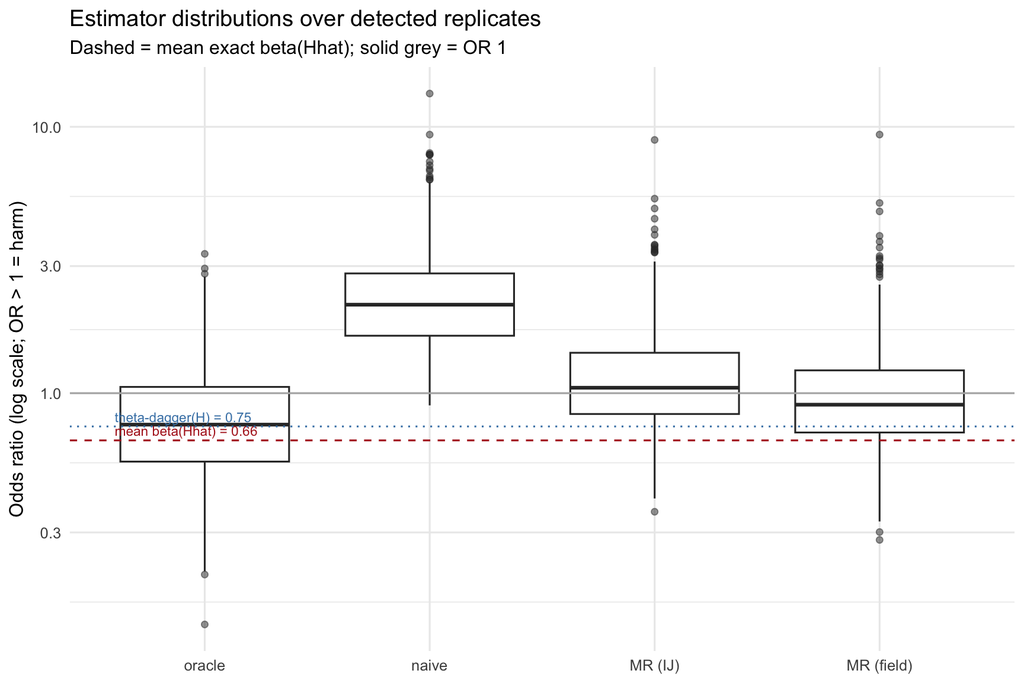

```r
if (nrow(rd)) {
  keys <- est_keys_for("H")
  long <- do.call(rbind, lapply(names(keys), function(lab)
    data.frame(Estimator = lab, est = .est_cols("H", keys[[lab]])$e)))
  long$Estimator <- factor(long$Estimator, levels = names(keys))
  bH_mean <- .mfin(rd$bH)
  p <- ggplot(long[is.finite(long$est) & long$est > 0, ], aes(x = Estimator, y = est)) +
    geom_boxplot(outlier.alpha = 0.5) +
    scale_y_log10() +
    geom_hline(yintercept = 1, linetype = 1, colour = "grey70") +
    geom_hline(yintercept = bH_mean, linetype = 2, colour = "firebrick") +
    annotate("text", x = 0.6, y = bH_mean, vjust = -0.5, hjust = 0, size = 3,
             colour = "firebrick", label = sprintf("mean beta(Hhat) = %.2f", bH_mean)) +
    labs(y = "Odds ratio (log scale; OR > 1 = harm)", x = NULL,
         title = "Estimator distributions over detected replicates",
         subtitle = "Dashed = mean exact beta(Hhat); solid grey = OR 1") +
    theme_minimal(base_size = 12)
  if (is.finite(oracle_ref))
    p <- p + geom_hline(yintercept = oracle_ref, linetype = 3, colour = "steelblue") +
      annotate("text", x = 0.6, y = oracle_ref, vjust = -0.5, hjust = 0, size = 3,
               colour = "steelblue", label = sprintf("theta-dagger(H) = %.2f", oracle_ref))
  p
}
```

# 8 MR (field) diagnostics

```r
# Coverage with Wilson intervals against all four targets, two-sided (primary
# per the estimator's own interval) and one-sided on the exposed side.
if (nrow(rd) && any(is.finite(rd$fld_H_est2))) {
  cov_rows <- function(sfx) {
    b <- .blk[[sfx]]; keys <- est_keys_for(sfx)
    side <- if (sfx == "H") "lower" else "upper"
    tgt <- list(oracle = rd[[b$or_col]], betaHhat = rd[[b$beta]],
                `theta-dagger` = b$dagger, `theta-ddagger` = b$ddagger)
    do.call(rbind, lapply(names(keys), function(lab) {
      ec <- .est_cols(sfx, keys[[lab]]); b1 <- .bound_of(sfx, keys[[lab]], side)
      do.call(rbind, lapply(names(tgt), function(tn) {
        c2 <- .cov_n(tgt[[tn]], ec$lo, ec$hi); w <- .wilson(c2[1], c2[2])
        c1 <- .cov1_n(tgt[[tn]], b1, side); w1 <- .wilson(c1[1], c1[2])
        data.frame(Block = if (sfx == "H") "Harm Hhat" else "Complement Hhat^c",
                   Estimator = lab, Target = tn, n = as.integer(c2[2]),
                   Cov2s = c2[1], W2_lo = w[1], W2_hi = w[2],
                   Cov1s = c1[1], W1_lo = w1[1], W1_hi = w1[2], Side = side,
                   stringsAsFactors = FALSE)
      }))
    }))
  }
  gt(rbind(cov_rows("H"), cov_rows("Hc")), groupname_col = "Block") |>
    tab_header(title = "95% coverage with Wilson intervals (two-sided; one-sided on the exposed side)",
               subtitle = sprintf("Targets: per-replicate oracle; beta(Hhat) (conditional, primary); theta-dagger; theta-ddagger. %s", .family_note)) |>
    fmt_number(columns = c(Cov2s, W2_lo, W2_hi, Cov1s, W1_lo, W1_hi), decimals = 3) |>
    cols_label(Cov2s = "2-sided", W2_lo = "Wilson lo", W2_hi = "Wilson hi",
               Cov1s = "1-sided", W1_lo = "Wilson lo", W1_hi = "Wilson hi", Side = "1-sided bound")
}
```

95% coverage with Wilson intervals (two-sided; one-sided on the exposed side)

Targets: per-replicate oracle; beta(Hhat) (conditional, primary); theta-dagger; theta-ddagger. DINA's candidate family is generated from a fitted surface, so every coverage figure below is coverage of the estimand CONDITIONAL ON THE PROPOSED FAMILY.

| Estimator | Target | n | 2-sided | Wilson lo | Wilson hi | 1-sided | Wilson lo | Wilson hi | 1-sided bound |
| --- | --- | --- | --- | --- | --- | --- | --- | --- | --- |
| Harm Hhat |  |  |  |  |  |  |  |  |  |
| oracle | oracle | 944 | 1.000 | 0.996 | 1.000 | 1.000 | 0.996 | 1.000 | lower |
| oracle | betaHhat | 944 | 0.945 | 0.928 | 0.958 | 0.908 | 0.888 | 0.925 | lower |
| oracle | theta-dagger | 944 | 0.951 | 0.936 | 0.963 | 0.943 | 0.926 | 0.956 | lower |
| oracle | theta-ddagger | 944 | 0.952 | 0.937 | 0.964 | 0.939 | 0.921 | 0.952 | lower |
| naive | oracle | 944 | 0.454 | 0.423 | 0.486 | 0.339 | 0.309 | 0.370 | lower |
| naive | betaHhat | 944 | 0.244 | 0.217 | 0.272 | 0.133 | 0.113 | 0.157 | lower |
| naive | theta-dagger | 944 | 0.383 | 0.353 | 0.415 | 0.222 | 0.197 | 0.250 | lower |
| naive | theta-ddagger | 944 | 0.359 | 0.329 | 0.390 | 0.207 | 0.182 | 0.234 | lower |
| MR (IJ) | oracle | 944 | 0.969 | 0.956 | 0.979 | 0.932 | 0.914 | 0.947 | lower |
| MR (IJ) | betaHhat | 944 | 0.988 | 0.979 | 0.993 | 0.965 | 0.951 | 0.975 | lower |
| MR (IJ) | theta-dagger | 944 | 0.996 | 0.989 | 0.998 | 0.979 | 0.968 | 0.986 | lower |
| MR (IJ) | theta-ddagger | 944 | 0.996 | 0.989 | 0.998 | 0.978 | 0.966 | 0.985 | lower |
| MR (field) | oracle | 944 | 0.890 | 0.868 | 0.908 | 0.854 | 0.830 | 0.875 | lower |
| MR (field) | betaHhat | 944 | 0.932 | 0.914 | 0.947 | 0.870 | 0.847 | 0.890 | lower |
| MR (field) | theta-dagger | 944 | 0.963 | 0.949 | 0.973 | 0.923 | 0.904 | 0.938 | lower |
| MR (field) | theta-ddagger | 944 | 0.956 | 0.940 | 0.967 | 0.912 | 0.892 | 0.929 | lower |
| Complement Hhat^c |  |  |  |  |  |  |  |  |  |
| oracle | oracle | 944 | 1.000 | 0.996 | 1.000 | 1.000 | 0.996 | 1.000 | upper |
| oracle | betaHhat | 944 | 0.959 | 0.944 | 0.970 | 0.962 | 0.948 | 0.972 | upper |
| oracle | theta-dagger | 944 | 0.962 | 0.948 | 0.972 | 0.966 | 0.953 | 0.976 | upper |
| oracle | theta-ddagger | 944 | 0.951 | 0.936 | 0.963 | 0.977 | 0.965 | 0.985 | upper |
| naive | oracle | 944 | 0.977 | 0.965 | 0.985 | 0.922 | 0.903 | 0.937 | upper |
| naive | betaHhat | 944 | 0.886 | 0.864 | 0.904 | 0.797 | 0.770 | 0.821 | upper |
| naive | theta-dagger | 944 | 0.903 | 0.882 | 0.920 | 0.822 | 0.796 | 0.845 | upper |
| naive | theta-ddagger | 944 | 0.922 | 0.903 | 0.937 | 0.873 | 0.850 | 0.893 | upper |
| MR (IJ) | oracle | 944 | 1.000 | 0.996 | 1.000 | 1.000 | 0.996 | 1.000 | upper |
| MR (IJ) | betaHhat | 944 | 1.000 | 0.996 | 1.000 | 0.999 | 0.994 | 1.000 | upper |
| MR (IJ) | theta-dagger | 944 | 1.000 | 0.996 | 1.000 | 0.999 | 0.994 | 1.000 | upper |
| MR (IJ) | theta-ddagger | 944 | 1.000 | 0.996 | 1.000 | 0.999 | 0.994 | 1.000 | upper |
| MR (field) | oracle | 944 | 1.000 | 0.996 | 1.000 | 0.994 | 0.986 | 0.997 | upper |
| MR (field) | betaHhat | 944 | 0.932 | 0.914 | 0.947 | 0.913 | 0.893 | 0.929 | upper |
| MR (field) | theta-dagger | 944 | 0.934 | 0.917 | 0.948 | 0.918 | 0.899 | 0.934 | upper |
| MR (field) | theta-ddagger | 944 | 0.948 | 0.932 | 0.961 | 0.935 | 0.918 | 0.949 | upper |

```
Table: Bias vs coverage, harm block (log-OR scale): bias_log = retained bias vs beta(Hhat) in log-OR units; b = bias / empirical SD, r = mean SE / empirical SD; *_ref = Gaussian bookkeeping prediction at (b, r). DINA's candidate family is generated from a fitted surface, so every coverage figure bel…

|cell                           |estimator |   n| bias_log| sd_emp| se_mean|    b|     r|  cov1|  cov2| cov1_ref| cov2_ref|
|:------------------------------|:---------|---:|--------:|------:|-------:|----:|-----:|-----:|-----:|--------:|--------:|
|target_or_h=0.75, n=500 [dina] |mr        | 944|    0.504|  0.413|   0.684| 1.22| 1.657| 0.965| 0.988|    0.934|    0.979|
|target_or_h=0.75, n=500 [dina] |fld       | 944|    0.358|  0.426|   0.474| 0.84| 1.112| 0.870| 0.932|    0.839|    0.908|
```

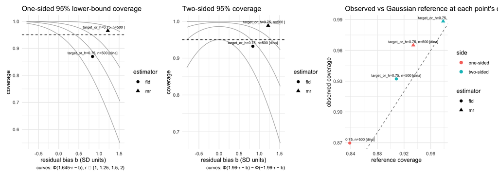

```r
# Bias-vs-coverage display for THIS cell on the LOG scale (the OR is a ratio
# measure): one point per estimator against the Gaussian bookkeeping reference.
if (nrow(rd) && any(is.finite(rd$fld_H_est2))) {
  .ests_H <- if (isTRUE(show_winner_rows) && any(is.finite(results$mr_H_se_w)))
    c("mr", "mr_w", "mr_wf", "fld") else c("mr", "fld")
  bc <- fs_sim_bias_coverage(res_or, block = "H", estimators = .ests_H, scale = "log")
  bc$cell <- cell_lab
  print(knitr::kable(bc[, c("cell", "estimator", "n", "bias_log", "sd_emp", "se_mean", "b", "r",
                            "cov1", "cov2", "cov1_ref", "cov2_ref")], digits = 3,
    caption = sprintf("Bias vs coverage, harm block (log-OR scale): bias_log = retained bias vs beta(Hhat) in log-OR units; b = bias / empirical SD, r = mean SE / empirical SD; *_ref = Gaussian bookkeeping prediction at (b, r). %s", .family_note)))
  print(fs_plot_bias_coverage(bc))
}
```

```r
if (nrow(rd) && any(is.finite(rd$fld_H_est2))) {
  ok <- is.finite(rd$bH)
  .ret <- function(est) {                        # retained bias vs beta(Hhat), OR difference
    d <- est[ok] - rd$bH[ok]; d <- d[is.finite(d)]
    c(mean = mean(d), sd_est = stats::sd(d), n = length(d))
  }
  rb_nv <- .ret(rd$nv_H_est); rb_mr <- .ret(rd$mr_H_est); rb_fld <- .ret(rd$fld_H_est2)
  sdl_fld <- .sdlog(rd$fld_H_est2); sdl_mr <- .sdlog(rd$mr_H_est); sdl_nv <- .sdlog(rd$nv_H_est)
  # Both stored SEs are on the WORKING (log-OR) scale, so both ratios are taken
  # against SD(log est).
  lam_ratio <- .mfin(rd$fld_H_se) / sdl_fld
  ij_ratio  <- .mfin(rd$mr_H_se_ij) / sdl_mr
  marg_fld <- .mfin(rd$mr_H_est - rd$fld_H_lo1s)
  marg_ij  <- .mfin(rd$mr_H_est - exp(log(rd$mr_H_est) - z95 * rd$mr_H_se_ij))
  hw_fld   <- .mfin((rd$fld_H_hi2s - rd$fld_H_lo2s) / 2)
  hw_ij    <- .mfin((rd$mr_H_hi - rd$mr_H_lo) / 2)
  print(knitr::kable(data.frame(
    quantity = c("naive retained bias vs beta(Hhat)  [OR diff.]",
                 "MR (IJ) retained bias vs beta(Hhat)  [OR diff.]",
                 "MR (field) est2 retained bias vs beta(Hhat)  [OR diff.]",
                 "naive retained bias  [SD units, log-OR]",
                 "MR (IJ) retained bias  [SD units, log-OR]",
                 "MR (field) est2 retained bias  [SD units, log-OR]",
                 "IJ SE / SD(log est)  (MR (IJ), both log-OR)",
                 "lambda-SD / SD(log est)  (MR (field), both log-OR)",
                 "one-sided LOWER margin, OR: MR (IJ)",
                 "one-sided LOWER margin, OR: MR (field)",
                 "two-sided half-width, OR: MR (IJ)",
                 "two-sided half-width, OR: MR (field)"),
    value = c(rb_nv["mean"], rb_mr["mean"], rb_fld["mean"],
              .biaslog(rd$nv_H_est, rd$bH) / sdl_nv,
              .biaslog(rd$mr_H_est, rd$bH) / sdl_mr,
              .biaslog(rd$fld_H_est2, rd$bH) / sdl_fld,
              ij_ratio, lam_ratio, marg_ij, marg_fld, hw_ij, hw_fld),
    n = c(rb_nv["n"], rb_mr["n"], rb_fld["n"], rb_nv["n"], rb_mr["n"], rb_fld["n"], rep(NA, 6))),
    digits = 4,
    caption = "Harm block: retained bias against the conditional target beta(Hhat) (OR difference and SD units on the log-OR scale), SE-calibration ratios, one-sided margins and half-widths."))
  print(knitr::kable(data.frame(
    metric = c("outer draws used (mean / min, of R_out = 1000)",
               "inner draws used per outer (mean, of R_in = 500)",
               "field block seconds (mean / median)",
               "replicates with a degenerate field (note set)"),
    value = c(sprintf("%.1f / %d", .mfin(rd$fld_H_nout), suppressWarnings(min(rd$fld_H_nout, na.rm = TRUE))),
              sprintf("%.1f", .mfin(rd$fld_H_nin_mean)),
              sprintf("%.2f / %.2f", .mfin(rd$fld_H_secs), .medfin(rd$fld_H_secs)),
              sprintf("%d of %d detected", sum(!is.na(rd$fld_H_note)), nrow(rd)))),
    caption = "MR (field) Monte Carlo draw usage and cost (detected replicates)."))
}
```

```
Table: Harm block: retained bias against the conditional target beta(Hhat) (OR difference and SD units on the log-OR scale), SE-calibration ratios, one-sided margins and half-widths.

|quantity                                                |  value|   n|
|:-------------------------------------------------------|------:|---:|
|naive retained bias vs beta(Hhat)  [OR diff.]           | 1.7518| 944|
|MR (IJ) retained bias vs beta(Hhat)  [OR diff.]         | 0.5425| 944|
|MR (field) est2 retained bias vs beta(Hhat)  [OR diff.] | 0.3863| 944|
|naive retained bias  [SD units, log-OR]                 | 2.8233| 944|
|MR (IJ) retained bias  [SD units, log-OR]               | 1.2202| 944|
|MR (field) est2 retained bias  [SD units, log-OR]       | 0.8398| 944|
|IJ SE / SD(log est)  (MR (IJ), both log-OR)             | 1.6569|  NA|
|lambda-SD / SD(log est)  (MR (field), both log-OR)      | 1.1116|  NA|
|one-sided LOWER margin, OR: MR (IJ)                     | 0.8291|  NA|
|one-sided LOWER margin, OR: MR (field)                  | 0.7529|  NA|
|two-sided half-width, OR: MR (IJ)                       | 2.4242|  NA|
|two-sided half-width, OR: MR (field)                    | 1.0837|  NA|


Table: MR (field) Monte Carlo draw usage and cost (detected replicates).

|metric                                           |value             |
|:------------------------------------------------|:-----------------|
|outer draws used (mean / min, of R_out = 1000)   |982.1 / 275       |
|inner draws used per outer (mean, of R_in = 500) |494.6             |
|field block seconds (mean / median)              |11.70 / 8.68      |
|replicates with a degenerate field (note set)    |0 of 944 detected |
```

```r
# Regime diagnostic: p-hat(Hhat), the winner's own re-selection frequency
# (near 1 = settled selection; below ~0.5 = tie regime).
if (nrow(rd) && any(is.finite(rd$p_hat_H))) {
  ph <- rd$p_hat_H[is.finite(rd$p_hat_H)]
  print(knitr::kable(data.frame(
    metric = c("mean p-hat(Hhat)", "median p-hat(Hhat)", "share p-hat(Hhat) < 0.5 (tie regime)",
               "share p-hat(Hhat) >= 0.9 (settled)", "mean top-1 p-hat",
               "share of replicates where the winner IS the modal candidate"),
    value = c(mean(ph), stats::median(ph), mean(ph < 0.5), mean(ph >= 0.9),
              .mfin(rd$p_top1), mean(rd$p_hat_H == rd$p_top1, na.rm = TRUE))), digits = 3,
    caption = "Re-selection frequencies (return_reselection = TRUE), detected replicates."))
  print(knitr::kable(data.frame(p_hat_bin = cut(ph, c(0, .25, .5, .75, .9, 1), include.lowest = TRUE)) |>
          table() |> as.data.frame() |> setNames(c("p_hat(Hhat) bin", "n")),
        caption = "Distribution of p-hat(Hhat)."))
}
```

```
Table: Re-selection frequencies (return_reselection = TRUE), detected replicates.

|metric                                                      | value|
|:-----------------------------------------------------------|-----:|
|mean p-hat(Hhat)                                            | 0.183|
|median p-hat(Hhat)                                          | 0.141|
|share p-hat(Hhat) < 0.5 (tie regime)                        | 0.958|
|share p-hat(Hhat) >= 0.9 (settled)                          | 0.001|
|mean top-1 p-hat                                            | 0.214|
|share of replicates where the winner IS the modal candidate | 0.525|


Table: Distribution of p-hat(Hhat).

|p_hat(Hhat) bin |   n|
|:---------------|---:|
|[0,0.25]        | 710|
|(0.25,0.5]      | 194|
|(0.5,0.75]      |  33|
|(0.75,0.9]      |   6|
|(0.9,1]         |   1|
```

```r
# Complement field block: retained bias against beta(Hhat^c), the complement's
# lambda-SD and IJ-SE calibration, the one-sided UPPER margins and half-widths,
# the regime diagnostics SD(beta-tilde^c)/naive SE and lambda-SD^c/naive SE, and
# the complement-fit accounting and cost.
if (nrow(rd) && any(is.finite(rd$fld_Hc_est2))) {
  okc <- is.finite(rd$bHc)
  .retc <- function(est) { d <- est[okc] - rd$bHc[okc]; d <- d[is.finite(d)]
    c(mean = mean(d), sd_est = stats::sd(d), n = length(d)) }
  rbc_nv <- .retc(rd$nv_Hc_est); rbc_mr <- .retc(rd$mr_Hc_est); rbc_fld <- .retc(rd$fld_Hc_est2)
  sdlc_fld <- .sdlog(rd$fld_Hc_est2); sdlc_mr <- .sdlog(rd$mr_Hc_est); sdlc_nv <- .sdlog(rd$nv_Hc_est)
  nv_se_c <- .mfin(rd$nv_Hc_se)    # WORKING (log-OR) scale, as are the two SEs below
  print(knitr::kable(data.frame(
    quantity = c("naive retained bias vs beta(Hhat^c)  [OR diff.]",
                 "MR (IJ) retained bias vs beta(Hhat^c)  [OR diff.]",
                 "MR (field) est2 retained bias vs beta(Hhat^c)  [OR diff.]",
                 "naive retained bias  [SD units, log-OR]",
                 "MR (IJ) retained bias  [SD units, log-OR]",
                 "MR (field) est2 retained bias  [SD units, log-OR]",
                 "IJ SE / SD(log est)  (MR (IJ), complement, both log-OR)",
                 "lambda-SD / SD(log est)  (MR (field), complement, both log-OR)",
                 "REGIME: SD(log beta-tilde^c) / naive SE (both log-OR)",
                 "REGIME: lambda-SD^c / naive SE (both log-OR)",
                 "one-sided UPPER margin, OR: MR (IJ)",
                 "one-sided UPPER margin, OR: MR (field)",
                 "one-sided UPPER margin, OR: MR (field-s)",
                 "two-sided half-width, OR: MR (IJ)",
                 "two-sided half-width, OR: MR (field)"),
    value = c(rbc_nv["mean"], rbc_mr["mean"], rbc_fld["mean"],
              .biaslog(rd$nv_Hc_est, rd$bHc) / sdlc_nv,
              .biaslog(rd$mr_Hc_est, rd$bHc) / sdlc_mr,
              .biaslog(rd$fld_Hc_est2, rd$bHc) / sdlc_fld,
              .mfin(rd$mr_Hc_se_ij) / sdlc_mr, .mfin(rd$fld_Hc_se) / sdlc_fld,
              sdlc_mr / nv_se_c,
              .mfin(rd$fld_Hc_se) / nv_se_c,
              .mfin(exp(log(rd$mr_Hc_est) + z95 * rd$mr_Hc_se_ij) - rd$mr_Hc_est),
              .mfin(rd$fld_Hc_up1s - rd$mr_Hc_est),
              .mfin(rd$fld_Hc_up1s_s - rd$mr_Hc_est),
              .mfin((rd$mr_Hc_hi - rd$mr_Hc_lo) / 2), .mfin((rd$fld_Hc_hi2s - rd$fld_Hc_lo2s) / 2)),
    n = c(rbc_nv["n"], rbc_mr["n"], rbc_fld["n"], rbc_nv["n"], rbc_mr["n"], rbc_fld["n"], rep(NA, 9))),
    digits = 4,
    caption = "Complement Hhat^c: retained bias against beta(Hhat^c) (OR difference and SD units on the log-OR scale), SE-calibration ratios, regime diagnostics, one-sided upper margins (field and field-s) and half-widths. Every SE-to-SD and SE-to-SE ratio is on the WORKING (log-OR) scale: the stored Wald / IJ SEs and the field's lambda-SD all live there (R/fs_mr_inference.R:480-488)."))
  print(knitr::kable(data.frame(
    metric = c("outer draws used (mean / min, of R_out = 1000)",
               "inner draws used per outer (mean, of R_in = 500)",
               "distinct complement fits per replicate (mean / max)",
               "share of draw-winner readings needing a new complement fit (mean / max)",
               "complement field block seconds (mean / median)",
               "replicates with a degenerate complement field (note set)"),
    value = c(sprintf("%.1f / %d", .mfin(rd$fld_Hc_nout), suppressWarnings(min(rd$fld_Hc_nout, na.rm = TRUE))),
              sprintf("%.1f", .mfin(rd$fld_Hc_nin_mean)),
              sprintf("%.1f / %d", .mfin(rd$fld_Hc_nfit), suppressWarnings(max(rd$fld_Hc_nfit, na.rm = TRUE))),
              sprintf("%.3f / %.3f", .mfin(rd$fld_Hc_share_newfit), suppressWarnings(max(rd$fld_Hc_share_newfit, na.rm = TRUE))),
              sprintf("%.2f / %.2f", .mfin(rd$fld_Hc_secs), .medfin(rd$fld_Hc_secs)),
              sprintf("%d of %d detected", sum(!is.na(rd$fld_Hc_note)), nrow(rd)))),
    caption = "Complement field: Monte Carlo draw usage, complement-fit accounting and cost (detected replicates)."))
}
```

```
Table: Complement Hhat^c: retained bias against beta(Hhat^c) (OR difference and SD units on the log-OR scale), SE-calibration ratios, regime diagnostics, one-sided upper margins (field and field-s) and half-widths. Every SE-to-SD and SE-to-SE ratio is on the WORKING (log-OR) scale: the stored Wald /…

|quantity                                                       |   value|   n|
|:--------------------------------------------------------------|-------:|---:|
|naive retained bias vs beta(Hhat^c)  [OR diff.]                | -0.1094| 944|
|MR (IJ) retained bias vs beta(Hhat^c)  [OR diff.]              | -0.0434| 944|
|MR (field) est2 retained bias vs beta(Hhat^c)  [OR diff.]      | -0.0271| 944|
|naive retained bias  [SD units, log-OR]                        | -1.0658| 944|
|MR (IJ) retained bias  [SD units, log-OR]                      | -0.4381| 944|
|MR (field) est2 retained bias  [SD units, log-OR]              | -0.3048| 944|
|IJ SE / SD(log est)  (MR (IJ), complement, both log-OR)        |  1.9619|  NA|
|lambda-SD / SD(log est)  (MR (field), complement, both log-OR) |  1.0042|  NA|
|REGIME: SD(log beta-tilde^c) / naive SE (both log-OR)          |  0.9587|  NA|
|REGIME: lambda-SD^c / naive SE (both log-OR)                   |  0.9832|  NA|
|one-sided UPPER margin, OR: MR (IJ)                            |  0.5537|  NA|
|one-sided UPPER margin, OR: MR (field)                         |  0.2682|  NA|
|one-sided UPPER margin, OR: MR (field-s)                       |  0.2698|  NA|
|two-sided half-width, OR: MR (IJ)                              |  0.5186|  NA|
|two-sided half-width, OR: MR (field)                           |  0.2592|  NA|


Table: Complement field: Monte Carlo draw usage, complement-fit accounting and cost (detected replicates).

|metric                                                                  |value             |
|:-----------------------------------------------------------------------|:-----------------|
|outer draws used (mean / min, of R_out = 1000)                          |982.1 / 275       |
|inner draws used per outer (mean, of R_in = 500)                        |494.6             |
|distinct complement fits per replicate (mean / max)                     |339.9 / 1464      |
|share of draw-winner readings needing a new complement fit (mean / max) |0.028 / 0.406     |
|complement field block seconds (mean / median)                          |0.27 / 0.21       |
|replicates with a degenerate complement field (note set)                |0 of 944 detected |
```

```
Table: Bias vs coverage, complement block (one-sided = UPPER bound; log-OR scale); the `fld_s` row is the field-s copy. DINA's candidate family is generated from a fitted surface, so every coverage figure below is coverage of the estimand CONDITIONAL ON THE PROPOSED FAMILY.

|cell                           |estimator |construction |   n| bias_log| sd_emp| se_mean|      b|     r|  cov1|  cov2| cov1_ref| cov2_ref|
|:------------------------------|:---------|:------------|---:|--------:|------:|-------:|------:|-----:|-----:|-----:|--------:|--------:|
|target_or_h=0.75, n=500 [dina] |mr        |IJ           | 944|   -0.086|  0.197|   0.387| -0.438| 1.962| 0.999| 1.000|    0.997|    1.000|
|target_or_h=0.75, n=500 [dina] |fld       |field        | 944|   -0.061|  0.202|   0.202| -0.305| 1.004| 0.913| 0.932|    0.911|    0.940|
|target_or_h=0.75, n=500 [dina] |fld_s     |field-s      | 944|   -0.062|  0.201|   0.204| -0.306| 1.013| 0.916| 0.936|    0.913|    0.943|
```

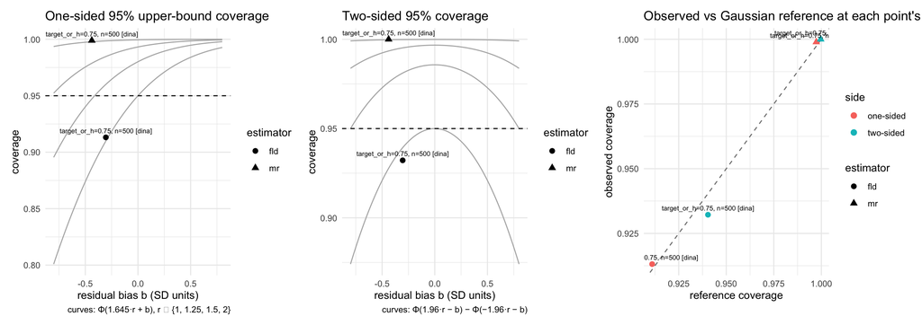

```r
# Complement display (block Hc, side upper, log scale).  The field-s copy: the
# nine fld_Hc_*_s columns are copied over their unstudentized names in a
# DUPLICATE frame, so fs_sim_bias_coverage() scores field-s without any rename
# elsewhere (task's naming disposition).
if (nrow(rd) && any(is.finite(rd$fld_Hc_est2))) {
  .ests_Hc <- if (isTRUE(show_winner_rows) && any(is.finite(results$mr_Hc_se_w)))
    c("mr", "mr_w", "mr_wf", "fld") else c("mr", "fld")
  bcc <- fs_sim_bias_coverage(res_or, block = "Hc", estimators = .ests_Hc,
                              side = "upper", scale = "log")
  bcc$cell <- cell_lab; bcc$construction <- ifelse(bcc$estimator == "fld", "field", "IJ")
  res_s <- res_or
  for (nm in c("est2", "up1s", "lo1s", "lo2s", "hi2s", "lo_se", "hi_se", "se", "lam_mean"))
    res_s[[paste0("fld_Hc_", nm)]] <- res_or[[paste0("fld_Hc_", nm, "_s")]]
  bcs <- try(fs_sim_bias_coverage(res_s, block = "Hc", estimators = "fld",
                                  side = "upper", scale = "log"), silent = TRUE)
  if (!inherits(bcs, "try-error")) {
    bcs$cell <- cell_lab; bcs$construction <- "field-s"; bcs$estimator <- "fld_s"
    bcc <- rbind(bcc, bcs)
  }
  print(knitr::kable(bcc[, c("cell", "estimator", "construction", "n", "bias_log", "sd_emp",
                             "se_mean", "b", "r", "cov1", "cov2", "cov1_ref", "cov2_ref")], digits = 3,
    caption = sprintf("Bias vs coverage, complement block (one-sided = UPPER bound; log-OR scale); the `fld_s` row is the field-s copy. %s", .family_note)))
  print(fs_plot_bias_coverage(bcc[bcc$construction != "field-s", , drop = FALSE], side = "upper"))
}
```

```r
# Simultaneous (H lower, Hc upper) pair: joint coverage of
# (beta(Hhat) >= lower_H AND beta(Hhat^c) <= upper_Hc) for the separate 95%
# bounds, the Bonferroni pair and the calibrated pair, for BOTH the
# unstudentized field pair and the field-s pair; margins in OR units.
if (nrow(rd) && any(is.finite(rd$fld_joint_gamma))) {
  rJ <- rd[is.finite(rd$bH) & is.finite(rd$bHc) & is.finite(rd$fld_joint_gamma), , drop = FALSE]
  .wl <- function(x, n) { w <- .wilson(x, n); sprintf("%.3f (%.3f, %.3f)", x, w[1], w[2]) }
  pairs <- list(
    `field: separate 95%`        = list(lo = rJ$fld_H_lo1s, up = rJ$fld_Hc_up1s),
    `field: Bonferroni`          = list(lo = rJ$fld_joint_bonf_loH, up = rJ$fld_joint_bonf_upHc),
    `field: calibrated gamma`    = list(lo = rJ$fld_joint_loH, up = rJ$fld_joint_upHc),
    `field-s: separate 95%`      = list(lo = rJ$fld_H_lo1s, up = rJ$fld_Hc_up1s_s),
    `field-s: Bonferroni`        = list(lo = rJ$fld_joint_s_bonf_loH, up = rJ$fld_joint_s_bonf_upHc),
    `field-s: calibrated gamma`  = list(lo = rJ$fld_joint_s_loH, up = rJ$fld_joint_s_upHc))
  jt <- do.call(rbind, lapply(names(pairs), function(nm) {
    p <- pairs[[nm]]
    okp <- is.finite(p$lo) & is.finite(p$up)
    if (!any(okp)) return(NULL)
    covH <- rJ$bH[okp] >= p$lo[okp]; covC <- rJ$bHc[okp] <= p$up[okp]
    data.frame(pair = nm, n = sum(okp), joint_cov = .wl(mean(covH & covC), sum(okp)),
               cov_H = mean(covH), cov_Hc = mean(covC),
               both_bounds = mean(okp),
               margin_H = mean(rJ$mr_H_est[okp] - p$lo[okp]),
               margin_Hc = mean(p$up[okp] - rJ$mr_Hc_est[okp]),
               stringsAsFactors = FALSE)
  }))
  print(knitr::kable(jt, digits = 3,
    caption = sprintf("Joint (Hhat lower, Hhat^c upper) coverage of (beta(Hhat), beta(Hhat^c)) with Wilson intervals; margins in OR units from the two-term de-biased estimates. `both_bounds` = share of the %d scored replicates carrying both bounds. Mean gamma = %.4f (joint %.3f; Bonferroni %.3f) and gamma_s = %.4f (joint %.3f; Bonferroni %.3f); mean corr(Lambda*, Lambda*c) = %+.3f (field-s %+.3f); n_joint_draws mean %.0f. %s",
                      nrow(rJ), mean(rJ$fld_joint_gamma), mean(rJ$fld_joint_prob), mean(rJ$fld_joint_bonf_prob),
                      mean(rJ$fld_joint_s_gamma, na.rm = TRUE), mean(rJ$fld_joint_s_prob, na.rm = TRUE),
                      mean(rJ$fld_joint_s_bonf_prob, na.rm = TRUE),
                      mean(rJ$fld_joint_corr), mean(rJ$fld_joint_s_corr, na.rm = TRUE),
                      mean(rJ$fld_joint_n), .family_note)))
}
```

```
Table: Joint (Hhat lower, Hhat^c upper) coverage of (beta(Hhat), beta(Hhat^c)) with Wilson intervals; margins in OR units from the two-term de-biased estimates. `both_bounds` = share of the 944 scored replicates carrying both bounds. Mean gamma = 0.0251 (joint 0.950; Bonferroni 0.950) and gamma_s = …

|pair                      |   n|joint_cov            | cov_H| cov_Hc| both_bounds| margin_H| margin_Hc|
|:-------------------------|---:|:--------------------|-----:|------:|-----------:|--------:|---------:|
|field: separate 95%       | 944|0.790 (0.763, 0.815) | 0.870|  0.913|           1|    0.753|     0.268|
|field: Bonferroni         | 944|0.878 (0.856, 0.898) | 0.938|  0.940|           1|    0.829|     0.326|
|field: calibrated gamma   | 944|0.878 (0.856, 0.898) | 0.938|  0.940|           1|    0.828|     0.326|
|field-s: separate 95%     | 944|0.793 (0.766, 0.818) | 0.870|  0.916|           1|    0.753|     0.270|
|field-s: Bonferroni       | 944|0.881 (0.859, 0.900) | 0.938|  0.943|           1|    0.829|     0.328|
|field-s: calibrated gamma | 944|0.881 (0.859, 0.900) | 0.938|  0.943|           1|    0.828|     0.328|
```

# 9 Identification

```r
if (nrow(rd)) {
  knitr::kable(data.frame(
    metric = c("sens", "spec", "ppv", "npv"),
    mean   = c(.mfin(rd$sens), .mfin(rd$spec), .mfin(rd$ppv), .mfin(rd$npv)),
    median = c(.medfin(rd$sens), .medfin(rd$spec), .medfin(rd$ppv), .medfin(rd$npv))),
    digits = 3, caption = "Classification of the identified subgroup vs the true harm flag (detected reps).")
}
```

Classification of the identified subgroup vs the true harm flag (detected reps).

| metric | mean | median |
| --- | --- | --- |
| sens | 0.207 | 0.161 |
| spec | 0.833 | 0.841 |
| ppv | 0.177 | 0.144 |
| npv | 0.858 | 0.853 |

```r
# Identifier family sizes: MR's kept family K, the consistency-qualifying table
# (FS only), the band count (FS only), the admitted/proposed counts (GRF / DINA).
if (nrow(rd)) {
  .rng <- function(x) { x <- x[is.finite(x)]
    if (!length(x)) "structurally NA on this path" else
      sprintf("min %g | median %g | mean %.1f | p90 %g | max %g (n %d)",
              min(x), stats::median(x), mean(x), stats::quantile(x, .9, names = FALSE), max(x), length(x)) }
  knitr::kable(data.frame(
    quantity = c("n_family (MR's kept family K)", "n_cons_qual (consistency-qualifying; FS only)",
                 "band_n (within the band on observed effects; FS only)",
                 "admitted_n (GRF forest-qualified / DINA admitted)",
                 "dina_searched_n", "dina_proposed_n", "dina_tau_min (oriented)",
                 "p_hat_sum (selection rate over the family)"),
    summary = c(.rng(rd$n_family), .rng(rd$n_cons_qual), .rng(rd$band_n), .rng(rd$admitted_n),
                .rng(rd$dina_searched_n), .rng(rd$dina_proposed_n), .rng(rd$dina_tau_min),
                .rng(rd$p_hat_sum)),
    stringsAsFactors = FALSE),
    caption = sprintf("Candidate-family accounting, detected replicates. %s", .family_note))
  wm <- results$warn_msg[!is.na(results$warn_msg)]
  cat(sprintf("\nWarnings: %d of %d rows carry warn_msg; distinct messages: %s\n",
              length(wm), nrow(results),
              if (length(wm)) paste(unique(gsub(" \\[x[0-9]+\\]", "", unlist(strsplit(wm, " | ", fixed = TRUE)))), collapse = " || ") else "none"))
}
```

[output not shown]

### 9.0.1 Selected-covariate frequencies and realized rules

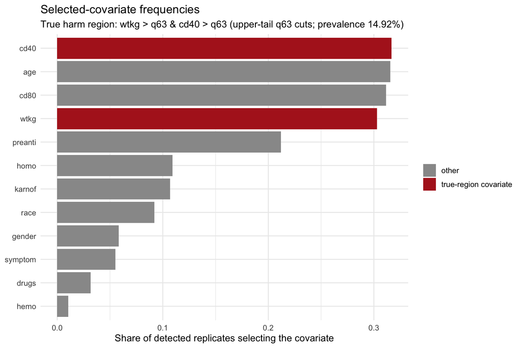

Realized rules (sg_def) by frequency, detected reps (top 25 of 870 distinct).

| rule | n | share |
| --- | --- | --- |
| {homo <= 0} & {gender >= 1} | 7 | 0.007 |
| {karnof <= 90} & {homo <= 0} | 7 | 0.007 |
| {age >= 34} & {homo <= 0} | 4 | 0.004 |
| {drugs <= 0} & {gender <= 0} | 4 | 0.004 |
| {drugs >= 1} | 4 | 0.004 |
| {homo <= 0} & {race <= 0} | 4 | 0.004 |
| {homo >= 1} & {race >= 1} | 4 | 0.004 |
| {karnof >= 100} & {homo <= 0} | 4 | 0.004 |
| {race >= 1} & {gender >= 1} | 4 | 0.004 |
| {age <= 28} & {hemo <= 0} | 3 | 0.003 |
| {age <= 30} & {homo <= 0} | 3 | 0.003 |
| {age <= 30} & {karnof <= 90} | 3 | 0.003 |
| {age >= 30} & {race >= 1} | 3 | 0.003 |
| {homo <= 0} & {race >= 1} | 3 | 0.003 |
| {karnof <= 90} & {race >= 1} | 3 | 0.003 |
| {age <= 26} | 2 | 0.002 |
| {age <= 28} & {gender >= 1} | 2 | 0.002 |
| {age <= 28} & {karnof >= 100} | 2 | 0.002 |
| {age <= 32} & {homo <= 0} | 2 | 0.002 |
| {age <= 32} & {karnof <= 90} | 2 | 0.002 |
| {age <= 32} & {karnof >= 100} | 2 | 0.002 |
| {age <= 32} & {race >= 1} | 2 | 0.002 |
| {age >= 26} & {gender <= 0} | 2 | 0.002 |
| {age >= 28} & {drugs >= 1} | 2 | 0.002 |
| {age >= 32} & {homo <= 0} | 2 | 0.002 |

```r
if (nrow(rd)) {
  cov_list  <- lapply(rd$sg_def, rule_covs)
  cov_all   <- unique(unlist(cov_list))
  if (length(cov_all)) {
    cf <- vapply(cov_all, function(v)
      mean(vapply(cov_list, function(x) v %in% x, logical(1))), numeric(1))
    cf_df <- data.frame(covariate = names(cf), share = unname(cf))
    cf_df$true_region <- cf_df$covariate %in% subgroup_vars
    print(
      ggplot(cf_df, aes(x = reorder(covariate, share), y = share, fill = true_region)) +
        geom_col() + coord_flip() +
        scale_fill_manual(values = c(`TRUE` = "firebrick", `FALSE` = "grey60"),
                          labels = c(`TRUE` = "true-region covariate", `FALSE` = "other"), name = NULL) +
        labs(x = NULL, y = "Share of detected replicates selecting the covariate",
             title = "Selected-covariate frequencies",
             subtitle = sprintf("True harm region: %s (upper-tail q%.0f cuts; prevalence %.2f%%)",
                                paste(sprintf("%s > q%.0f", subgroup_vars, 100 * sg_quantile), collapse = " & "),
                                100 * sg_quantile, 100 * truth$prevalence_Q)) +
        theme_minimal(base_size = 12))
    rules <- sort(table(rd$sg_def), decreasing = TRUE)
    knitr::kable(data.frame(rule = names(utils::head(rules, 25L)),
                            n = as.integer(utils::head(rules, 25L)),
                            share = as.numeric(utils::head(rules, 25L)) / nrow(rd)),
      digits = 3, caption = sprintf("Realized rules (sg_def) by frequency, detected reps (top 25 of %d distinct).", length(rules)))
  }
}
```

# 10 Timing

```r
.dist_row <- function(x) {
  x <- x[is.finite(x)]
  if (!length(x)) return(rep(NA_real_, 14))
  c(min = min(x), stats::quantile(x, probs = seq(0.1, 0.9, 0.1)),
    median = stats::median(x), mean = mean(x), max = max(x), n = length(x))
}
tim <- rbind(fit_mr_secs = .dist_row(results$fit_mr_secs),
             id_secs     = .dist_row(results$id_secs),
             fld_H_secs  = .dist_row(results$fld_H_secs),
             fld_Hc_secs = .dist_row(results$fld_Hc_secs))
knitr::kable(tim, digits = 2,
  caption = sprintf("Per-replicate seconds (all replicates; %s mode, %d workers). fit_mr_secs INCLUDES the field blocks.",
                    parallel_mode, n_workers))
```

Per-replicate seconds (all replicates; sims mode, 13 workers). fit_mr_secs INCLUDES the field blocks.

|  | min | 10% | 20% | 30% | 40% | 50% | 60% | 70% | 80% | 90% | median | mean | max | n |
| --- | --- | --- | --- | --- | --- | --- | --- | --- | --- | --- | --- | --- | --- | --- |
| fit_mr_secs | 0.05 | 3.82 | 5.36 | 6.78 | 8.07 | 9.72 | 11.79 | 15.01 | 19.35 | 29.29 | 9.72 | 13.61 | 71.64 | 1000 |
| id_secs | 0.04 | 0.07 | 0.14 | 0.22 | 0.32 | 0.48 | 0.66 | 0.98 | 1.47 | 2.57 | 0.48 | 0.97 | 7.87 | 1000 |
| fld_H_secs | 0.81 | 4.22 | 5.44 | 6.36 | 7.47 | 8.68 | 10.27 | 12.66 | 16.01 | 23.01 | 8.68 | 11.70 | 56.56 | 944 |
| fld_Hc_secs | 0.01 | 0.04 | 0.06 | 0.10 | 0.14 | 0.21 | 0.27 | 0.36 | 0.47 | 0.59 | 0.21 | 0.27 | 1.17 | 944 |

```r
mr_mean <- .mfin(results$fit_mr_secs)
fmt_hm <- function(sec) {
  if (!is.finite(sec)) return("-")
  h <- floor(sec / 3600); m <- round((sec - 3600 * h) / 60)
  if (h >= 1) sprintf("%d h %02d m", h, m) else sprintf("%d m", round(sec / 60))
}
wall_model <- function(ns) ceiling(ns / n_workers) * mr_mean
k_cal <- if (is.finite(elapsed) && wall_model(n_batch) > 0) elapsed / wall_model(n_batch) else NA_real_
proj <- do.call(rbind, lapply(c(n_batch, 1000L, 2000L), function(ns)
  data.frame(n_sims = ns, per_rep_s = round(mr_mean, 2), cpu_hours = round(ns * mr_mean / 3600, 2),
             wall_model = fmt_hm(wall_model(ns)),
             wall_calibrated = fmt_hm(if (is.finite(k_cal)) k_cal * wall_model(ns) else NA_real_))))
proj$wall_actual <- c(fmt_hm(elapsed), "-", "-")
cat(sprintf("This run: %d reps in %s on %d workers; per rep fit+MR(+field) %.2f s%s.\n",
            n_batch, if (is.finite(elapsed)) sprintf("%.0f s", elapsed) else "- (combine)", n_workers, mr_mean,
            if (is.finite(k_cal)) sprintf("; realized overhead factor k = %.2f", k_cal) else ""))
```

```
This run: 1000 reps in - (combine) on 13 workers; per rep fit+MR(+field) 13.61 s.
```

```r
knitr::kable(proj, caption = "Wall-clock projection: ceil(sims / workers) x per-rep cost, and k x that.")
```

Wall-clock projection: ceil(sims / workers) x per-rep cost, and k x that.

| n_sims | per_rep_s | cpu_hours | wall_model | wall_calibrated | wall_actual |
| --- | --- | --- | --- | --- | --- |
| 1000 | 13.61 | 3.78 | 17 m | - | - |
| 1000 | 13.61 | 3.78 | 17 m | - | - |
| 2000 | 13.61 | 7.56 | 35 m | - | - |

```r
.fmt_dur <- function(s) {
  h <- s %/% 3600; m <- (s %% 3600) %/% 60; sec <- round(s %% 60)
  if (h >= 1) sprintf("%d h %02d m %02d s", h, m, sec)
  else if (m >= 1) sprintf("%d m %02d s", m, sec)
  else sprintf("%.1f s", s)
}
.secs_total <- as.numeric(difftime(Sys.time(), .t0_doc, units = "secs"))
cat(sprintf("TOTAL wall-clock, start to finish: %s  (= %.0f s; %d reps on %d workers)\n",
            .fmt_dur(.secs_total), .secs_total, n_batch, n_workers))
```

```
TOTAL wall-clock, start to finish: 6.0 s  (= 6 s; 1000 reps on 13 workers)
```

```r
if (is.finite(elapsed)) cat(sprintf("  of which the run loop: %s\n", .fmt_dur(elapsed)))
```